# Análisis Exploratorio de Datos (EDA) - Proyecto de Transporte - Andando

### General: Objetivos del Proyecto y Definición de Variables

El objetivo principal de este proyecto es desarrollar un modelo basado en **Máquinas de Vectores de Soporte (SVM)** para predecir el **modo de transporte** utilizado por un individuo en función de los datos recopilados por sensores de dispositivos móviles. Se busca analizar cómo las diferentes señales captadas por el acelerómetro, giróscopo, barómetro, GPS y magnetómetro pueden ser utilizadas para inferir con precisión el medio de transporte en uso.

Para lograr esto, se cuenta con un conjunto de datos que incluye:

1. **Registro Temporal**
   - Cada observación está asociada a un instante de tiempo específico.
2. **Datos de Movimiento y Orientación**
   - **Acelerómetro**: Componentes X, Y, Z del vector aceleración.
   - **Giróscopo**: Velocidad angular en los ejes X, Y, Z y su derivada.
   - **Matriz de Rotación y Cuaterniones**: Representan la orientación tridimensional del dispositivo.
3. **Datos de Ubicación y Contexto**
   - **GPS**: Coordenadas de latitud y longitud, velocidad, altitud y rumbo.
   - **Presión Atmosférica**: Valores obtenidos del barómetro, junto con la altitud relativa.
   - **Campo Magnético Terrestre**: Medición en los ejes X, Y, Z.
4. **Variables Categóricas**
   - **Modo de Transporte**: La categoría que se busca predecir (caminar, bicicleta, automóvil, etc.).
   - **Nivel de Confianza**: Un indicador de la precisión estimada para la clasificación del transporte en los datos originales.

### Objetivo Notebook: Alcance del Análisis

El análisis exploratorio de datos (EDA) busca comprender la estructura del dataset, identificar patrones y evaluar la calidad de los datos antes de proceder con el modelado. Se incluyen tareas como:

- **Identificación y tratamiento de outliers univariantes y multivariantes.**
- **Evaluación de la normalidad y distribución de las variables.**
- **Exploración de la correlación entre variables para determinar redundancias o relaciones clave.**
- **Selección de variables relevantes para el modelo.**

# **1. Carga de librerías**

```r
# Lista de paquetes necesarios
necessary_packages <- c("dplyr", "ggplot2", "DataExplorer", "naniar",
                        "moments", "psych", "caret", "lubridate", "chemometrics",
                        "tidyr", "tidyverse", "cowplot", "car")

# Instalar paquetes que no están instalados
new_packages <- necessary_packages[!(necessary_packages %in% installed.packages()[, "Package"])]
if (length(new_packages) > 0) {
  install.packages(new_packages)
}

# Cargar todos los paquetes
lapply(necessary_packages, library, character.only = TRUE)
```

[output not shown]

[output cut: 9 more lines]

[output not shown]

```r
# Cargar las librerías
library(lubridate)
library(dplyr)
library(ggplot2)
library(naniar)
library(moments)
library(psych)
library(caret)
library(reshape2)
library(geosphere)
library(zoo)
# Cargar librerías necesarias
library(ggplot2)
library(gridExtra) # Para organizar múltiples gráficos
library(ggpubr)    # Para Q-Q plots
library(chemometrics)
library(knitr)      # Para formatear tablas
library(kableExtra) # Para mejorar la presentación
library(GGally)
```

# 2. Cargar el dataset

```r
# Ruta del archivo CSV (modificar según tu sistema)
ruta_dataset <- "C:/Users/Lenovo/Documents/IT Academy/Datos proyecto 8/proyect8/input_data/100Hz-v5_20240128_131700_50s-andando.csv"

data <- read.csv(ruta_dataset)

# Resumen del dataset
cat("### Información General del Dataset")
```

```
### Información General del Dataset
```

```r
dim(data) # Dimensiones del dataset
```

```
[1] 4976   44
```

```r
str(data) # Estructura del dataset
```

```
'data.frame':   4976 obs. of  44 variables:
 $ Timestamp               : chr  "28-Jan-2024 13:17:10.140" "28-Jan-2024 13:17:10.150" "28-Jan-2024 13:17:10.160" "28-Jan-2024 13:17:10.170" ...
 $ accelX.g.               : num  -0.483 -0.485 -0.486 -0.497 -0.496 ...
 $ accelY.g.               : num  0.879 0.848 0.836 0.822 0.792 ...
 $ accelZ.g.               : num  -0.64 -0.665 -0.681 -0.673 -0.661 ...
 $ accelUserX.g.           : num  -0.0875 -0.0886 -0.0872 -0.0967 -0.0985 -0.0873 -0.0639 -0.0052 -0.0016 0.0046 ...
 $ accelUserY.g.           : num  0.1564 0.1263 0.113 0.1024 0.0767 ...
 $ accelUserZ.g.           : num  -0.077 -0.0983 -0.1184 -0.1125 -0.1001 ...
 $ gyroX.rad.s.            : num  0.3705 0.2513 0.1528 0.0942 0.0504 ...
 $ gyroY.rad.s.            : num  -0.4153 -0.263 -0.12 0.008 0.0879 ...
 $ gyroZ.rad.s.            : num  -0.286 -0.259 -0.216 -0.164 -0.123 ...
 $ Roll.rads.              : num  -0.613 -0.615 -0.616 -0.616 -0.616 ...
 $ Pitch.rads.             : num  -0.816 -0.813 -0.811 -0.809 -0.808 ...
 $ Yaw.rads.               : num  1.07 1.07 1.07 1.07 1.07 ...
 $ m11                     : num  0.0209 0.0207 0.021 0.0222 0.0229 0.0237 0.0231 0.0173 0.0161 0.0133 ...
```

[output cut: 30 more lines]

```r
summary(data) # Resumen estadístico básico
```

```
  Timestamp           accelX.g.         accelY.g.        accelZ.g.       accelUserX.g.      accelUserY.g.       accelUserZ.g.        gyroX.rad.s.      gyroY.rad.s.        gyroZ.rad.s.
 Length:4976        Min.   :-0.8582   Min.   :0.0128   Min.   :-1.5853   Min.   :-0.38710   Min.   :-0.330900   Min.   :-0.763000   Min.   :-1.9580   Min.   :-4.737200   Min.   :-1.58780
 Class :character   1st Qu.:-0.5971   1st Qu.:0.3589   1st Qu.:-0.8476   1st Qu.:-0.05663   1st Qu.:-0.081525   1st Qu.:-0.091100   1st Qu.:-0.5573   1st Qu.:-0.772675   1st Qu.:-0.38620
 Mode  :character   Median :-0.4109   Median :0.4602   Median :-0.7543   Median : 0.00505   Median :-0.014350   Median :-0.013400   Median : 0.1308   Median : 0.243600   Median : 0.00200
                    Mean   :-0.4206   Mean   :0.4529   Mean   :-0.7388   Mean   : 0.01046   Mean   :-0.009502   Mean   : 0.004902   Mean   :-0.0112   Mean   : 0.002974   Mean   : 0.01763
                    3rd Qu.:-0.2642   3rd Qu.:0.5383   3rd Qu.:-0.6302   3rd Qu.: 0.06845   3rd Qu.: 0.057625   3rd Qu.: 0.082725   3rd Qu.: 0.5129   3rd Qu.: 0.901975   3rd Qu.: 0.37650
                    Max.   : 0.1059   Max.   :1.0124   Max.   :-0.2727   Max.   : 0.32870   Max.   : 0.532200   Max.   : 0.478300   Max.   : 1.4216   Max.   : 3.352900   Max.   : 1.79440
   Roll.rads.       Pitch.rads.        Yaw.rads.            m11                m12               m13               m21               m22               m23               m31
 Min.   :-0.8404   Min.   :-0.9552   Min.   :-0.3314   Min.   :-0.33900   Min.   :-0.1028   Min.   :-0.0341   Min.   :-0.9830   Min.   :-0.0864   Min.   :-0.8164   Min.   :-0.8670
 1st Qu.:-0.6685   1st Qu.:-0.5801   1st Qu.: 1.1525   1st Qu.:-0.12020   1st Qu.: 0.7275   1st Qu.: 0.3216   1st Qu.:-0.9031   1st Qu.: 0.1073   1st Qu.:-0.5481   1st Qu.:-0.5609
 Median :-0.4847   Median :-0.5048   Median : 1.3641   Median :-0.03035   Median : 0.8690   Median : 0.3908   Median :-0.8416   Median : 0.1832   Median :-0.4836   Median :-0.4834
 Mean   :-0.5161   Mean   :-0.4874   Mean   : 1.1378   Mean   : 0.11568   Mean   : 0.7492   Mean   : 0.4309   Mean   :-0.7023   Mean   : 0.2832   Mean   :-0.4624   Mean   :-0.4678
 3rd Qu.:-0.3982   3rd Qu.:-0.3623   3rd Qu.: 1.4486   3rd Qu.: 0.12220   3rd Qu.: 0.9290   3rd Qu.: 0.5772   3rd Qu.:-0.7115   3rd Qu.: 0.3080   3rd Qu.:-0.3545   3rd Qu.:-0.3615
 Max.   : 0.0439   Max.   :-0.1740   Max.   : 1.6711   Max.   : 0.99010   Max.   : 0.9700   Max.   : 0.7242   Max.   : 0.2686   Max.   : 0.9669   Max.   :-0.1732   Max.   :-0.1101
      m32               m33               qX                 qY                qZ                qW              Lat             Long         Speed.m.s.      TrueHeading        Alt.m.
 Min.   :-0.7472   Min.   :0.4957   Min.   :-0.33670   Min.   :-0.4510   Min.   :-0.0923   Min.   :0.5673   Min.   :41.39   Min.   :2.117   Min.   :0.0092   Min.   :168.3   Min.   :82.21
 1st Qu.:-0.5315   1st Qu.:0.7065   1st Qu.:-0.13332   1st Qu.:-0.3613   1st Qu.: 0.5520   1st Qu.:0.6555   1st Qu.:41.39   1st Qu.:2.117   1st Qu.:1.6871   1st Qu.:181.5   1st Qu.:82.82
 Median :-0.3422   Median :0.7481   Median :-0.06585   Median :-0.3397   Median : 0.6300   Median :0.6889   Median :41.39   Median :2.117   Median :2.3397   Median :186.6   Median :83.12
 Mean   :-0.2609   Mean   :0.7437   Mean   :-0.05569   Mean   :-0.3180   Mean   : 0.5331   Mean   :0.7242   Mean   :41.39   Mean   :2.117   Mean   :2.0688   Mean   :199.6   Mean   :83.43
 3rd Qu.:-0.1832   3rd Qu.:0.7874   3rd Qu.: 0.05495   3rd Qu.:-0.2975   3rd Qu.: 0.6606   3rd Qu.:0.7334   3rd Qu.:41.39   3rd Qu.:2.118   3rd Qu.:2.5996   3rd Qu.:197.0   3rd Qu.:84.17
 Max.   : 0.6458   Max.   :0.8801   Max.   : 0.21760   Max.   :-0.0696   Max.   : 0.7370   Max.   :0.9664   Max.   :41.39   Max.   :2.118   Max.   :3.1351   Max.   :282.6   Max.   :84.64
 HorizontalAccuracy.m. VerticalAccuracy.m.     Course      ActivityType       ActivityConfidence Pressure.kilopascals. RelativeAltitude.meters.    magX.µT.         magY.µT.
 Min.   : 6.000        Min.   :3           Min.   :232.9   Length:4976        Length:4976        Min.   :102.0         Min.   :34.98            Min.   : 72.51   Min.   : 79.57
 1st Qu.: 6.000        1st Qu.:3           1st Qu.:249.1   Class :character   Class :character   1st Qu.:102.0         1st Qu.:35.81            1st Qu.: 82.80   1st Qu.: 86.33
 Median : 6.000        Median :3           Median :254.9   Mode  :character   Mode  :character   Median :102.0         Median :36.72            Median : 90.45   Median : 91.53
 Mean   : 6.351        Mean   :3           Mean   :267.9                                         Mean   :102.0         Mean   :36.58            Mean   : 92.44   Mean   : 94.71
 3rd Qu.: 6.000        3rd Qu.:3           3rd Qu.:263.7                                         3rd Qu.:102.1         3rd Qu.:37.25            3rd Qu.: 96.94   3rd Qu.: 98.99
 Max.   :25.000        Max.   :3           Max.   :345.7                                         Max.   :102.1         Max.   :38.29            Max.   :126.35   Max.   :124.97
    magZ.µT.       calMagX.µT.      calMagY.µT.       calMagZ.µT.
 Min.   :-682.4   Min.   :-31.64   Min.   :-16.389   Min.   :-49.26
 1st Qu.:-676.9   1st Qu.:-21.45   1st Qu.: -9.575   1st Qu.:-43.90
 Median :-675.2   Median :-13.76   Median : -4.383   Median :-42.16
 Mean   :-673.9   Mean   :-11.80   Mean   : -1.233   Mean   :-40.82
 3rd Qu.:-671.4   3rd Qu.: -7.39   3rd Qu.:  3.157   3rd Qu.:-38.27
 Max.   :-660.0   Max.   : 21.90   Max.   : 29.040   Max.   :-27.25
```

La variable `Timestamp` se encuentra en formato `chr` (cadena de texto), lo que requiere convertirla a un formato de fecha y hora (`POSIXct`) para facilitar su análisis temporal.

Adicionalmente, se han identificado variables como **`Lat`**, **`Long`**, **`Speed.m.s.`**, **`TrueHeading`**, **`Alt.m.`**, **`HorizontalAccuracy.m.`**, **`VerticalAccuracy.m.`** y **`Course`** que no se encuentran en otros dataset y **no pueden ser calculadas, asi como** se requiere **unicidad en la estructura de los datos** para asegurar una integración adecuada, se decide eliminarlas, manteniendo solo las variables que pueden ser comparadas o utilizadas en el análisis conjunto.

#### 2.1. Convertir Timestamp de chr

```r
head(data$Timestamp)
```

```
[1] "28-Jan-2024 13:17:10.140" "28-Jan-2024 13:17:10.150" "28-Jan-2024 13:17:10.160" "28-Jan-2024 13:17:10.170" "28-Jan-2024 13:17:10.180" "28-Jan-2024 13:17:10.191"
```

```r
# Convertir Timestamp con parse_date_time
data <- data %>%
  mutate(Timestamp = parse_date_time(Timestamp, orders = "dmy HMSOS"))

# Verificar el resultado
head(data$Timestamp)
```

```
[1] "2020-01-29 00:13:27 UTC" "2020-01-29 00:13:27 UTC" "2020-01-29 00:13:27 UTC" "2020-01-29 00:13:27 UTC" "2020-01-29 00:13:27 UTC" "2020-01-29 00:13:27 UTC"
```

```r
class(data$Timestamp)  # Debería ser POSIXct
```

```
[1] "POSIXct" "POSIXt"
```

#### 2.2. Eliminar variables

```r
# Eliminar las columnas específicas del dataset
data <- data %>%
  select(-Lat, -Long, -Speed.m.s., -TrueHeading, -Alt.m., -HorizontalAccuracy.m., -VerticalAccuracy.m., -Course)
# Verificar las columnas restantes
colnames(data)
```

```
 [1] "Timestamp"                "accelX.g."                "accelY.g."                "accelZ.g."                "accelUserX.g."            "accelUserY.g."            "accelUserZ.g."
 [8] "gyroX.rad.s."             "gyroY.rad.s."             "gyroZ.rad.s."             "Roll.rads."               "Pitch.rads."              "Yaw.rads."                "m11"
[15] "m12"                      "m13"                      "m21"                      "m22"                      "m23"                      "m31"                      "m32"
[22] "m33"                      "qX"                       "qY"                       "qZ"                       "qW"                       "ActivityType"             "ActivityConfidence"
[29] "Pressure.kilopascals."    "RelativeAltitude.meters." "magX.µT."                 "magY.µT."                 "magZ.µT."                 "calMagX.µT."              "calMagY.µT."
[36] "calMagZ.µT."
```

```r
str(data)
```

```
'data.frame':   4976 obs. of  36 variables:
 $ Timestamp               : POSIXct, format: "2020-01-29 00:13:27" "2020-01-29 00:13:27" "2020-01-29 00:13:27" "2020-01-29 00:13:27" ...
 $ accelX.g.               : num  -0.483 -0.485 -0.486 -0.497 -0.496 ...
 $ accelY.g.               : num  0.879 0.848 0.836 0.822 0.792 ...
 $ accelZ.g.               : num  -0.64 -0.665 -0.681 -0.673 -0.661 ...
 $ accelUserX.g.           : num  -0.0875 -0.0886 -0.0872 -0.0967 -0.0985 -0.0873 -0.0639 -0.0052 -0.0016 0.0046 ...
 $ accelUserY.g.           : num  0.1564 0.1263 0.113 0.1024 0.0767 ...
 $ accelUserZ.g.           : num  -0.077 -0.0983 -0.1184 -0.1125 -0.1001 ...
 $ gyroX.rad.s.            : num  0.3705 0.2513 0.1528 0.0942 0.0504 ...
 $ gyroY.rad.s.            : num  -0.4153 -0.263 -0.12 0.008 0.0879 ...
 $ gyroZ.rad.s.            : num  -0.286 -0.259 -0.216 -0.164 -0.123 ...
 $ Roll.rads.              : num  -0.613 -0.615 -0.616 -0.616 -0.616 ...
 $ Pitch.rads.             : num  -0.816 -0.813 -0.811 -0.809 -0.808 ...
 $ Yaw.rads.               : num  1.07 1.07 1.07 1.07 1.07 ...
 $ m11                     : num  0.0209 0.0207 0.021 0.0222 0.0229 0.0237 0.0231 0.0173 0.0161 0.0133 ...
```

[output cut: 22 more lines]

# 3. Estadísticas Descriptivas

Las estadísticas descriptivas ofrecen una visión inicial sobre el rango, la distribución y los valores típicos de las variables. Esto permite identificar patrones generales y posibles anomalías.

## **3.1 Variables Numéricas**

Se analizan las variables numéricas mediante histogramas y medidas descriptivas para evaluar su distribución y detectar valores atípicos.

```r
# Seleccionar columnas numéricas
num_data <- data %>% select(where(is.numeric))

# Verificar si hay columnas numéricas
if (ncol(num_data) > 0) {
  cat("### Estadísticas para Variables Numéricas\n")

  # Imprimir estadísticas descriptivas básicas
  print(describe(num_data)) # Estadísticas básicas

} else {
  cat("No hay variables numéricas en el dataset.\n")
}
```

```
### Estadísticas para Variables Numéricas
```

|  | vars | n | mean | sd | median | trimmed | mad | min | max | range | skew | kurtosis | se |
| --- | --- | --- | --- | --- | --- | --- | --- | --- | --- | --- | --- | --- | --- |
| accelX.g. | 1 | 4976 | -0.42 | 0.19 | -0.41 | -0.42 | 0.24 | -0.86 | 0.11 | 0.96 | 0.01 | -0.96 | 0.00 |
| accelY.g. | 2 | 4976 | 0.45 | 0.16 | 0.46 | 0.45 | 0.13 | 0.01 | 1.01 | 1.00 | 0.14 | 0.33 | 0.00 |
| accelZ.g. | 3 | 4976 | -0.74 | 0.18 | -0.75 | -0.74 | 0.16 | -1.59 | -0.27 | 1.31 | -0.16 | 0.90 | 0.00 |
| accelUserX.g. | 4 | 4976 | 0.01 | 0.09 | 0.01 | 0.01 | 0.09 | -0.39 | 0.33 | 0.72 | 0.30 | 0.57 | 0.00 |
| accelUserY.g. | 5 | 4976 | -0.01 | 0.11 | -0.01 | -0.01 | 0.10 | -0.33 | 0.53 | 0.86 | 0.44 | 1.06 | 0.00 |
| accelUserZ.g. | 6 | 4976 | 0.00 | 0.16 | -0.01 | 0.00 | 0.13 | -0.76 | 0.48 | 1.24 | 0.15 | 1.14 | 0.00 |
| gyroX.rad.s. | 7 | 4976 | -0.01 | 0.70 | 0.13 | 0.02 | 0.72 | -1.96 | 1.42 | 3.38 | -0.40 | -0.81 | 0.01 |
| gyroY.rad.s. | 8 | 4976 | 0.00 | 1.35 | 0.24 | 0.11 | 1.15 | -4.74 | 3.35 | 8.09 | -0.70 | 0.41 | 0.02 |
| gyroZ.rad.s. | 9 | 4976 | 0.02 | 0.61 | 0.00 | 0.00 | 0.57 | -1.59 | 1.79 | 3.38 | 0.19 | -0.22 | 0.01 |
| Roll.rads. | 10 | 4976 | -0.52 | 0.17 | -0.48 | -0.52 | 0.18 | -0.84 | 0.04 | 0.88 | 0.12 | -0.32 | 0.00 |

[output cut: 23 more lines]

```r
NA
```

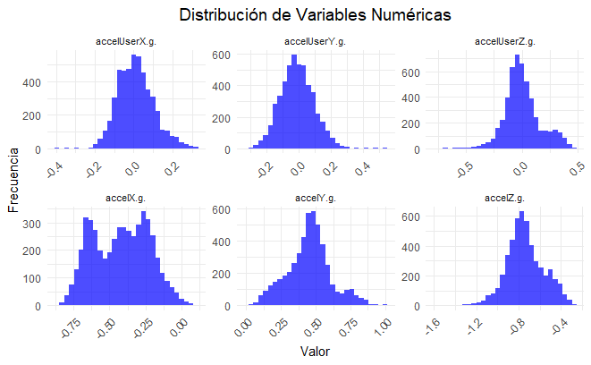

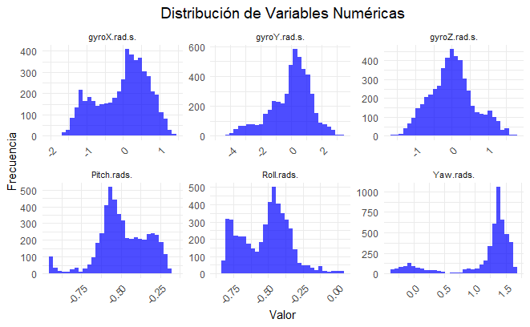

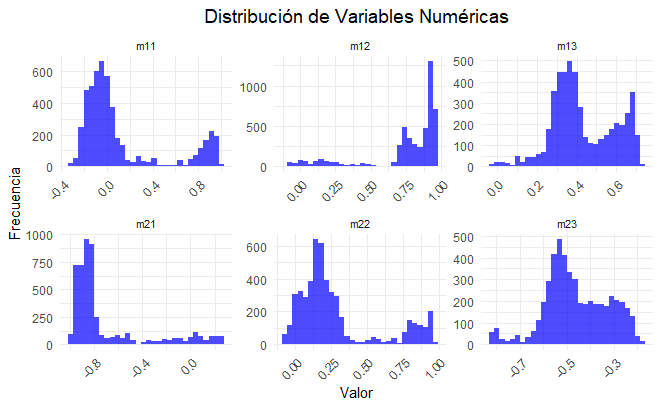

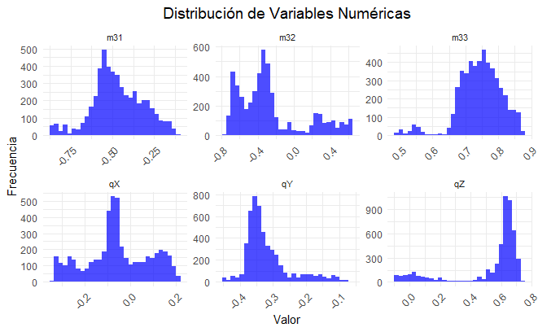

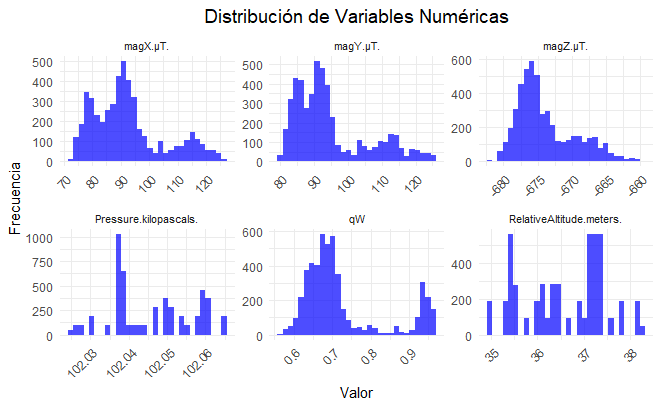

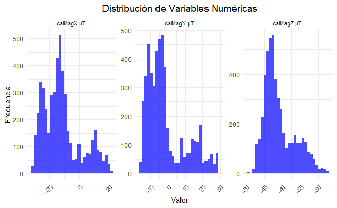

```r
library(tidyr)

# Visualización: Histogramas de Variables Numéricas
# Visualización: Histogramas de Variables Numéricas
# Dividir las variables en grupos de 9
variable_groups <- split(names(num_data), ceiling(seq_along(names(num_data)) / 6))

for (group in variable_groups) {
  # Filtrar las variables del grupo actual
  group_data <- num_data %>% select(all_of(group))

  # Convertir a formato largo
  group_data_long <- group_data %>%
    pivot_longer(cols = everything(), names_to = "Variable", values_to = "Valor")

  # Crear los gráficos
  print(
    ggplot(group_data_long, aes(x = Valor)) +
      geom_histogram(bins = 30, fill = "blue", alpha = 0.7) +
      facet_wrap(~ Variable, scales = "free", ncol = 3) +
      theme_minimal() +
      theme(
        strip.text = element_text(size = 8),
        axis.text.x = element_text(angle = 45, hjust = 1),
        plot.title = element_text(size = 14, hjust = 0.5)
      ) +
      labs(title = "Distribución de Variables Numéricas",
           x = "Valor",
           y = "Frecuencia")
  )
}
```

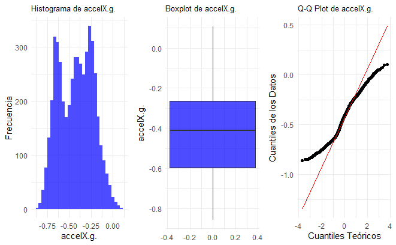

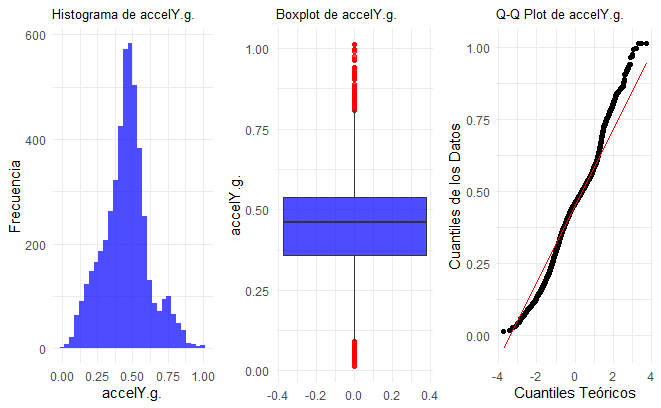

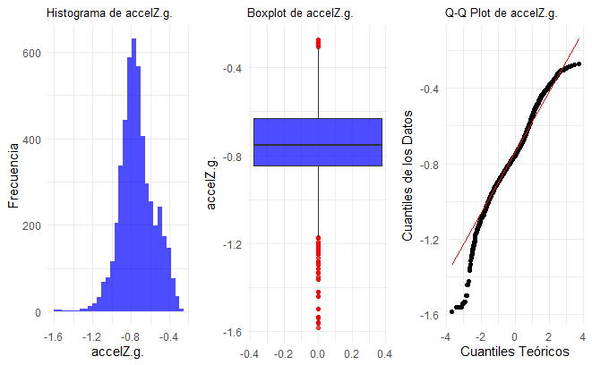

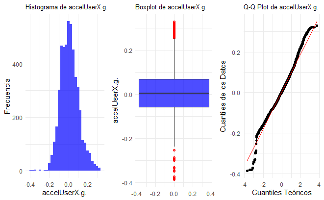

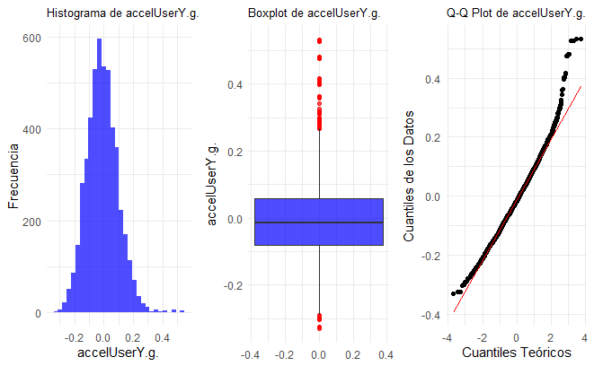

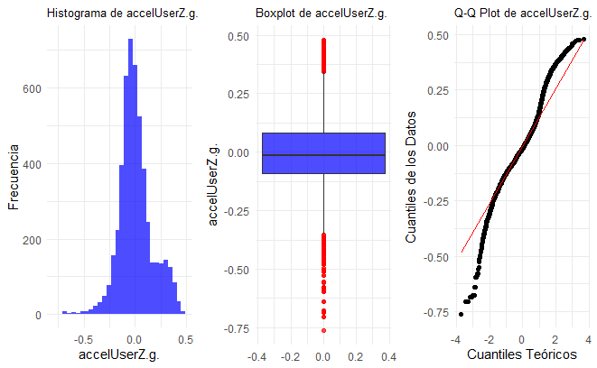

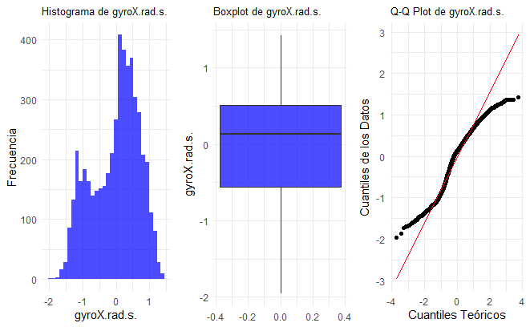

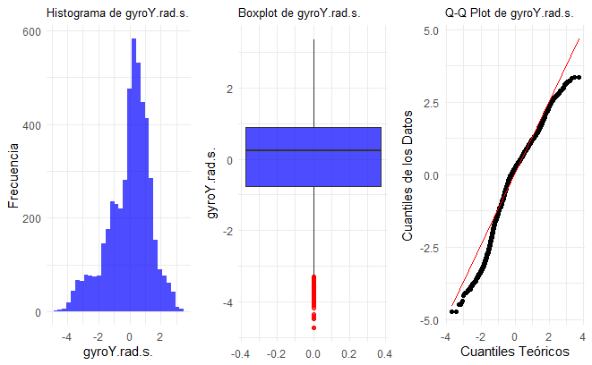

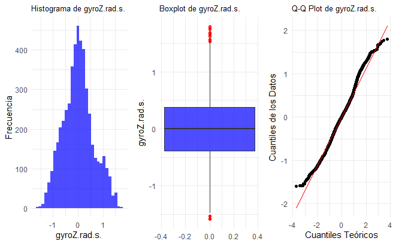

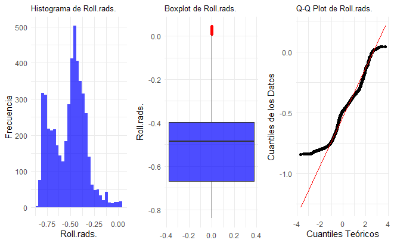

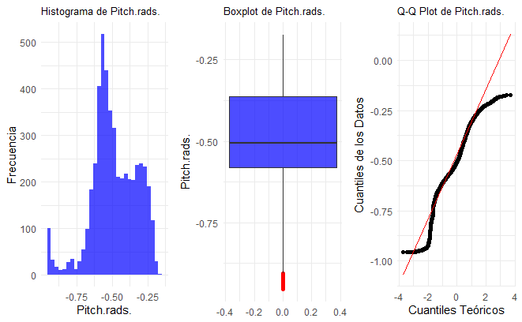

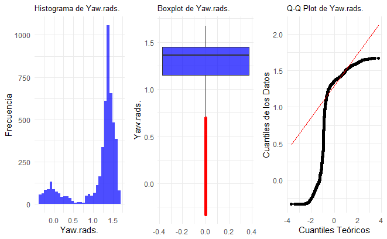

[21 more figures not shown]

```r
# Cargar librerías necesarias
library(tidyverse)
library(cowplot)

# Eliminar valores NA en num_data
num_data_clean <- num_data %>% drop_na()

# Confirmar que hay variables numéricas
if (ncol(num_data_clean) > 0) {
  # Iterar sobre las variables numéricas
  for (var in names(num_data_clean)) {
    # Crear histogramas
    hist_plot <- ggplot(num_data_clean, aes(x = !!sym(var))) +
      geom_histogram(bins = 30, fill = "blue", alpha = 0.7) +
      theme_minimal() +
      labs(title = paste("Histograma de", var), x = var, y = "Frecuencia") +
      theme(plot.title = element_text(size = 10))  # Ajuste de tamaño de título

    # Crear boxplots
    box_plot <- ggplot(num_data_clean, aes(y = !!sym(var))) +
      geom_boxplot(fill = "blue", alpha = 0.7, outlier.color = "red") +
      theme_minimal() +
      labs(title = paste("Boxplot de", var), y = var) +
      theme(plot.title = element_text(size = 10))  # Ajuste de tamaño de título

    # Crear Q-Q plots
    qq_plot <- ggplot(num_data_clean, aes(sample = !!sym(var))) +
      stat_qq() +
      stat_qq_line(color = "red") +
      theme_minimal() +
      labs(title = paste("Q-Q Plot de", var), x = "Cuantiles Teóricos", y = "Cuantiles de los Datos") +
      theme(plot.title = element_text(size = 10))  # Ajuste de tamaño de título

    # Mostrar los gráficos en una cuadrícula
    print(plot_grid(hist_plot, box_plot, qq_plot, ncol = 3))
  }
} else {
  cat("No hay variables numéricas en el dataset.\n")
}
```

```r
NA
NA
```

## 3.2 Variables Categóricas

Las variables categóricas se analizan para evaluar el balance de las clases, especialmente la variable objetivo.

```r
# Convertir la columna Timestamp a formato fecha y hora
data <- data %>%
  mutate(Timestamp = as.POSIXct(Timestamp, format = "%d-%b-%Y %H:%M:%OS"))

# Convertir las columnas character restantes en factor
data <- data %>%
  mutate(across(where(is.character), as.factor))

# Seleccionar las variables categóricas
cat_data <- data %>% select(where(is.factor))

# Verificar las estadísticas de variables categóricas
if (ncol(cat_data) > 0) {
  cat("### Estadísticas para Variables Categóricas\n")
  print(sapply(cat_data, table))
}
```

```
### Estadísticas para Variables Categóricas
$ActivityType

Walking
   4976

$ActivityConfidence

High  Med
3063 1913
```

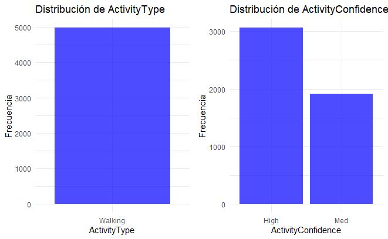

```r
# Gráficos de barras para cada variable categórica
# Crear una lista para almacenar los gráficos
plot_list <- list()

# Crear gráficos de barras para cada variable categórica y almacenarlos en la lista
for (var in names(cat_data)) {
  p <- ggplot(cat_data, aes_string(x = var)) +
    geom_bar(fill = "blue", alpha = 0.7) +
    theme_minimal() +
    labs(title = paste("Distribución de", var),
         x = var,
         y = "Frecuencia") +
    theme(axis.text.x = element_text(angle = 0, hjust = 0.5)) # Categorías horizontales

  # Agregar el gráfico a la lista
  plot_list[[var]] <- p
}

# Combinar todos los gráficos en una sola hoja
grid.arrange(grobs = plot_list, ncol = 2) # Ajusta ncol para cambiar las columnas
```

Algunas observaciones sobre las variables categoricas:

1. **Distribución de `ActivityType`**:
   - Sólo hay un tipo de actividad en los datos: “Walking”. Esto podría ser una limitación significativa si el objetivo es predecir modos de transporte variados. Es importante verificar si esta es una muestra representativa o si se requiere un conjunto de datos más diverso.
2. **Distribución de `ActivityConfidence`**:
   - La confianza en la actividad (`ActivityConfidence`) tiene dos niveles: “High” (3063 observaciones) y “Med” (1913 observaciones).
   - La mayoría de las observaciones tienen un nivel de confianza alto, lo cual es positivo para el análisis, ya que indica que los datos pueden ser más fiables.

# 4. Análisis de Valores Faltantes y Outliers

## 4.1 Detección de Valores faltantes

Identificar valores faltantes es crucial porque pueden afectar el rendimiento del modelo predictivo. Este paso ayuda a decidir estrategias para imputar o manejar estos valores.

```r
cat("### Análisis de Valores Faltantes\n")
```

```
### Análisis de Valores Faltantes
```

```r
# Resumen de valores faltantes por columna
print(sapply(data, function(x) sum(is.na(x))))
```

```
               Timestamp                accelX.g.                accelY.g.                accelZ.g.            accelUserX.g.            accelUserY.g.            accelUserZ.g.
                       0                        0                        0                        0                        0                        0                        0
            gyroX.rad.s.             gyroY.rad.s.             gyroZ.rad.s.               Roll.rads.              Pitch.rads.                Yaw.rads.                      m11
                       0                        0                        0                        0                        0                        0                        0
                     m12                      m13                      m21                      m22                      m23                      m31                      m32
                       0                        0                        0                        0                        0                        0                        0
                     m33                       qX                       qY                       qZ                       qW             ActivityType       ActivityConfidence
                       0                        0                        0                        0                        0                        0                        0
   Pressure.kilopascals. RelativeAltitude.meters.                 magX.µT.                 magY.µT.                 magZ.µT.              calMagX.µT.              calMagY.µT.
                       0                        0                        0                        0                        0                        0                        0
             calMagZ.µT.
                       0
```

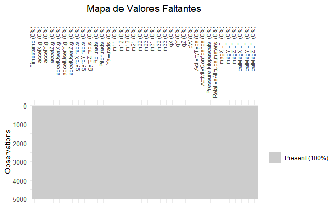

```r
# Visualización de valores faltantes mejorada
vis_miss(data) +
  ggtitle("Mapa de Valores Faltantes") +
  theme_minimal() +
  theme(
    axis.text.x = element_text(angle = 90, hjust = 1, size = 8), # Ajuste de las etiquetas del eje X
    axis.text.y = element_text(size = 10),                       # Ajuste de las etiquetas del eje Y
    plot.title = element_text(hjust = 0.5, size = 14)            # Centrar y ajustar tamaño del título
  )
```

```r
NA
NA
```

El análisis muestra que no hay valores nulos en el dataset. Esto significa que todas las variables contienen información completa para las 4976 observaciones registradas. Este resultado asegura que no será necesario realizar técnicas de imputación de datos.

## 4.2 Detección de Outliers Univariantes

Usaremos el rango intercuartílico (IQR) para identificar outliers y calcular el porcentaje de valores extremos en cada variable numérica.

```r
if (ncol(num_data) > 0) {
  cat("### Análisis de Outliers\n")

  # Cálculo de outliers por IQR
  outlier_detection <- num_data %>%
    summarise(across(everything(), ~ {
      q1 <- quantile(.x, 0.25, na.rm = TRUE)
      q3 <- quantile(.x, 0.75, na.rm = TRUE)
      iqr <- q3 - q1
      sum(.x < (q1 - 1.5 * iqr) | .x > (q3 + 1.5 * iqr), na.rm = TRUE) / length(.x) * 100
    }))

  # Transponer la tabla
  outlier_detection <- as.data.frame(t(outlier_detection))
  outlier_detection$Variable <- rownames(outlier_detection)
  rownames(outlier_detection) <- NULL

  # Reordenar las columnas
  outlier_detection <- outlier_detection %>%
    select(Variable, `Outliers (%)` = V1) %>%
    arrange(desc(`Outliers (%)`))  # Ordenar de mayor a menor

  # Mostrar la tabla
  print(outlier_detection)
}
```

```
### Análisis de Outliers
```

| Variable | Outliers (%) |
| --- | --- |
| m11 | 17.8657556 |
| qW | 17.6848875 |
| qZ | 17.4839228 |
| m22 | 17.3834405 |
| Yaw.rads. | 17.2829582 |
| m21 | 16.8810289 |
| m12 | 14.4091640 |
| m32 | 10.8721865 |
| qY | 9.8472669 |
| magY.µT. | 5.0844051 |

[output cut: 23 more lines]

**Visualización de Outliers**

Utilizaremos boxplots para visualizar los outliers en cada variable numérica.

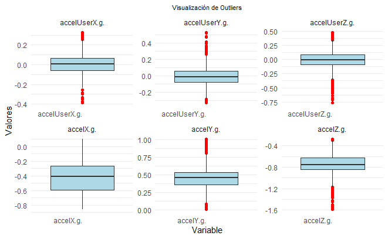

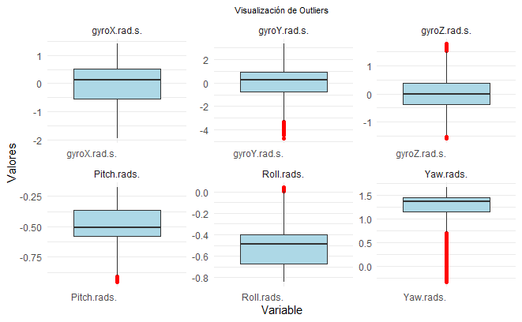

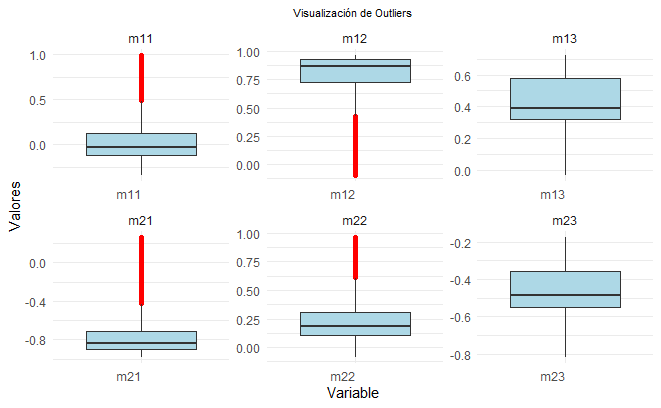

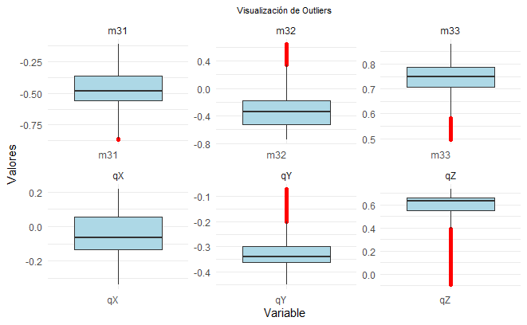

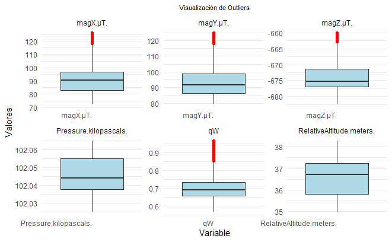

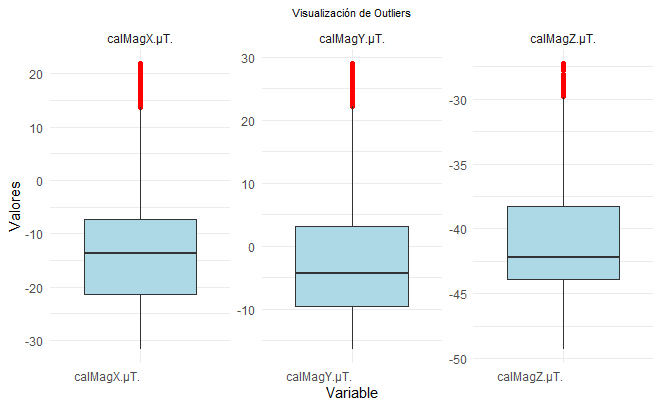

```r
if (ncol(num_data) > 0) {
  # Transformar datos a formato largo
  num_data_long <- num_data %>%
    pivot_longer(cols = everything(), names_to = "Variable", values_to = "Valor")

  # Dividir las variables en grupos de 6
  variable_groups <- split(unique(num_data_long$Variable), ceiling(seq_along(unique(num_data_long$Variable)) / 6))

  for (group in variable_groups) {
    # Filtrar las variables del grupo actual
    group_data_long <- num_data_long %>% filter(Variable %in% group)

    # Crear los boxplots
    print(
      ggplot(group_data_long, aes(x = Variable, y = Valor)) +
        geom_boxplot(outlier.colour = "red", outlier.size = 1.5, fill = "lightblue") +
        theme_minimal() +
        labs(
          title = "Visualización de Outliers",
          x = "Variable",
          y = "Valores"
        ) +
        theme(
          plot.title = element_text(size = 8, hjust = 0.5),
          axis.text.x = element_text(angle = 0, hjust = 1)
        ) +
        facet_wrap(~ Variable, scales = "free", ncol = 3)  # Cambia "ncol" a 2 o 3 según el diseño que prefieras
    )
  }
} else {
  cat("No hay variables numéricas en el dataset.\n")
}
```

### **Resultados del Análisis Univariado de Outliers**

1. **Variables con alto porcentaje de outliers (≥10%)**:
   - Las siguientes variables presentaron un porcentaje significativo de valores atípicos:
     - `m11` (17.86%)
     - `qW` (17.68%)
     - `qZ` (17.48%)
     - `m22` (17.38%)
     - `Yaw.rads` (17.28%)
     - `m21` (16.88%)
     - `m12` (14.40%)
     - `m32` (10.87%)
   - Estas variables están relacionadas con la orientación y dinámica del sistema.
     - **Matrices de rotación (`m11 - m33`)**: Capturan la orientación del dispositivo en el espacio tridimensional.
     - **Cuaterniones (`qW`, `qZ`)**: Representan otra forma de describir la orientación del dispositivo.
     - **`Yaw.rads`**: Describe la orientación angular del dispositivo en un plano horizontal.
2. **Outliers en Sensores de Movimiento y Magnetómetros:**
   - Las variables `calMagX.µT`, `calMagY.µT`, `calMagZ.µT` mostraron outliers extremos, posiblemente asociados con anomalías o interferencias en los campos magnéticos.
   - En las aceleraciones (`accelUserX(g)`, `accelUserY(g)`, `accelUserZ(g)`), los outliers pueden reflejar eventos dinámicos como impactos o movimientos bruscos.

#### **Relevancia de los Outliers**

- Los valores atípicos identificados en las matrices de rotación y cuaterniones pueden reflejar eventos reales, como cambios bruscos en la orientación del dispositivo.
- Los outliers en las variables de aceleración y giroscopio pueden indicar maniobras bruscas o vibraciones del sistema, que podrían ser esenciales para caracterizar el comportamiento del transporte.

#### **Recomendaciones para Manejo de Outliers**

1. **Análisis de Relevancia:**
   - Verificar el contexto de los outliers para determinar si representan eventos dinámicos significativos.
2. **Transformaciones de Variables:**
   - Aplicar transformaciones logarítmicas o robustas en variables como `qW`, `qZ`, `Yaw.rads`, `m11`, y `m22` para mitigar el impacto de los valores extremos.
3. **Validación del Impacto:**
   - Evaluar el impacto de los outliers en modelos predictivos para decidir si deben ser suavizados mediante técnicas como winsorización o mantenidos para capturar eventos reales.

## 4.3 Multivariate Outliers

Dado que varias variables tienen un porcentaje significativo de outliers univariados, recomiendo realizar un **análisis multivariante** para identificar combinaciones de valores extremos que no son evidentes en análisis univariados.

#### **Variables Recomendadas para Análisis Multivariante de Outliers:**

1. `m11`, `m22`, `m21`, `m12` (componentes de la matriz de rotación).
2. `qW`, `qZ` (cuaterniones).
3. `Yaw.rads` (orientación angular horizontal).
4. `calMagX.µT`, `calMagY.µT`, `calMagZ.µT` (campo magnético calibrado).

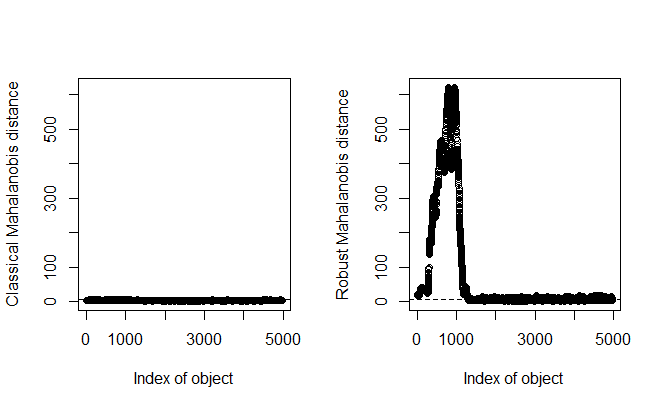

```r
# Cargar la librería
library(chemometrics)

# Crear una copia del dataset original para trabajar
data_analysis <- data

# Seleccionar las variables continuas con mayor porcentaje de outliers (>10%)
selected_vars <- data_analysis %>%
  select(m11, m22, qW, qZ, Yaw.rads., accelUserX.g., magX.µT., magY.µT., magZ.µT.)

# Calcular las distancias de Mahalanobis (clásica y robusta)
res.out <- Moutlier(selected_vars, quantile = 0.9999)
```

```r
# Inspeccionar resultados
str(res.out)
```

```
List of 3
 $ md    : num [1:4976] 3.96 3.96 3.92 3.94 3.94 ...
 $ rd    : num [1:4976] 20.7 20.5 20.5 20.5 20.5 ...
 $ cutoff: num 5.81
```

```r
# Visualizar outliers multivariantes
par(mfrow = c(1, 1)) # Una sola ventana de gráfico
plot(res.out$md, res.out$rd,
     xlab = "Mahalanobis Clásica",
     ylab = "Mahalanobis Robusta",
     main = "Outliers Multivariantes con Distancias de Mahalanobis")
abline(h = res.out$cutoff, col = "red") # Umbral robusto
```

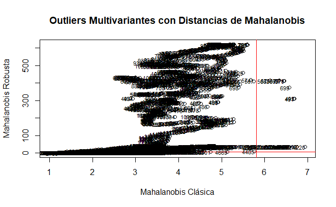

```r
abline(v = res.out$cutoff, col = "red") # Umbral clásico
text(res.out$md, res.out$rd, labels = rownames(data_analysis), adj = 1, cex = 0.7)
```

```r
# Identificar observaciones que son outliers multivariantes
outlier_indices <- which((res.out$md > res.out$cutoff) & (res.out$rd > res.out$cutoff))
cat("Observaciones outliers multivariantes:\n")
```

```
Observaciones outliers multivariantes:
```

```r
print(outlier_indices)
```

```
 [1] 200 201 202 203 204 205 206 207 208 209 210 211 212 213 214 215 216 217 218 219 220 221 222 223 224 225 226 227 228 229 230 231 232 233 234 235 236 491 492 568 569 570 571 572 573 699
```

```r
# Crear un nuevo dataset con la columna de outliers sin afectar el original
data_with_outliers <- data_analysis %>%
  mutate(outlier_multivar = ifelse(row_number() %in% outlier_indices, "Outlier", "No Outlier"))

# Resumen de la nueva variable en el dataset modificado
table(data_with_outliers$outlier_multivar)
```

```
No Outlier    Outlier
      4930         46
```

Para visualizar estos outliers, se generó un gráfico bivariado que muestra las distancias clásicas frente a las robustas. Los puntos fuera de las líneas rojas en el gráfico representan las observaciones más atípicas, las cuales merecen un análisis más detallado.

```r
# Mostrar un resumen de las filas marcadas como outliers
summary(data_with_outliers %>% filter(outlier_multivar == "Outlier"))
```

```
   Timestamp                        accelX.g.         accelY.g.        accelZ.g.       accelUserX.g.     accelUserY.g.      accelUserZ.g.       gyroX.rad.s.      gyroY.rad.s.
 Min.   :2020-01-29 00:13:29.14   Min.   :-0.3974   Min.   :0.1820   Min.   :-0.9170   Min.   :-0.2866   Min.   :-0.09200   Min.   :-0.07190   Min.   :-0.2874   Min.   :-1.8305
 1st Qu.:2020-01-29 00:13:29.27   1st Qu.:-0.2567   1st Qu.:0.6551   1st Qu.:-0.6223   1st Qu.:-0.1855   1st Qu.:-0.04185   1st Qu.: 0.01243   1st Qu.: 0.3261   1st Qu.: 0.4046
 Median :2020-01-29 00:13:29.36   Median :-0.2182   Median :0.7529   Median :-0.6022   Median :-0.1623   Median : 0.02030   Median : 0.06810   Median : 0.4729   Median : 0.4648
 Mean   :2020-01-29 00:13:30.02   Mean   :-0.2393   Mean   :0.6860   Mean   :-0.5957   Mean   :-0.1062   Mean   : 0.01104   Mean   : 0.07120   Mean   : 0.3639   Mean   : 0.4081
 3rd Qu.:2020-01-29 00:13:29.48   3rd Qu.:-0.1938   3rd Qu.:0.8386   3rd Qu.:-0.5595   3rd Qu.:-0.1290   3rd Qu.: 0.05792   3rd Qu.: 0.09767   3rd Qu.: 0.5069   3rd Qu.: 0.5804
 Max.   :2020-01-29 00:13:34.26   Max.   :-0.1229   Max.   :0.8613   Max.   :-0.4489   Max.   : 0.2965   Max.   : 0.13860   Max.   : 0.20360   Max.   : 0.6973   Max.   : 0.8232
  gyroZ.rad.s.        Roll.rads.        Pitch.rads.        Yaw.rads.            m11              m12              m13                m21               m22              m23
 Min.   :-0.58120   Min.   :-0.74140   Min.   :-0.9397   Min.   :-0.0414   Min.   :0.2276   Min.   :0.1533   Min.   :-0.00850   Min.   :-0.6719   Min.   :0.1923   Min.   :-0.8074
 1st Qu.:-0.19460   1st Qu.:-0.12348   1st Qu.:-0.8964   1st Qu.: 1.2138   1st Qu.:0.2503   1st Qu.:0.9374   1st Qu.: 0.01125   1st Qu.:-0.6349   1st Qu.:0.1953   1st Qu.:-0.7811
 Median :-0.05145   Median :-0.07555   Median :-0.8487   Median : 1.2427   Median :0.2925   Median :0.9560   Median : 0.04735   Median :-0.5964   Median :0.2089   Median :-0.7504
 Mean   :-0.07787   Mean   :-0.16473   Mean   :-0.7631   Mean   : 0.9998   Mean   :0.3826   Mean   :0.8065   Mean   : 0.13265   Mean   :-0.4937   Mean   :0.3503   Mean   :-0.6774
 3rd Qu.: 0.02668   3rd Qu.:-0.01682   3rd Qu.:-0.7853   3rd Qu.: 1.2544   3rd Qu.:0.3483   3rd Qu.:0.9669   3rd Qu.: 0.07402   3rd Qu.:-0.5679   3rd Qu.:0.2444   3rd Qu.:-0.7070
 Max.   : 0.30360   Max.   : 0.01180   Max.   :-0.2691   Max.   : 1.2562   Max.   :0.9131   Max.   :0.9700   Max.   : 0.65110   Max.   : 0.0398   Max.   :0.9635   Max.   :-0.2658
      m31               m32              m33               qX                qY                qZ               qW          ActivityType ActivityConfidence Pressure.kilopascals.
 Min.   :-0.8022   Min.   :0.1315   Min.   :0.5824   Min.   :-0.3322   Min.   :-0.3570   Min.   :0.0307   Min.   :0.7104   Walking:46    High: 0            Min.   :102.1
 1st Qu.:-0.7647   1st Qu.:0.1663   1st Qu.:0.6225   1st Qu.:-0.3295   1st Qu.:-0.2928   1st Qu.:0.5279   1st Qu.:0.7187                 Med :46            1st Qu.:102.1
 Median :-0.7217   Median :0.2066   Median :0.6606   Median :-0.3255   Median :-0.2745   Median :0.5372   Median :0.7351                                    Median :102.1
 Mean   :-0.7037   Mean   :0.2114   Mean   :0.6665   Mean   :-0.2949   Mean   :-0.2706   Mean   :0.4422   Mean   :0.7702                                    Mean   :102.1
 3rd Qu.:-0.6679   3rd Qu.:0.2313   3rd Qu.:0.7072   3rd Qu.:-0.3149   3rd Qu.:-0.2347   3rd Qu.:0.5427   3rd Qu.:0.7583                                    3rd Qu.:102.1
 Max.   :-0.4021   Max.   :0.4701   Max.   :0.8512   Max.   :-0.1308   Max.   :-0.1861   Max.   :0.5434   Max.   :0.9610                                    Max.   :102.1
 RelativeAltitude.meters.    magX.µT.         magY.µT.        magZ.µT.       calMagX.µT.      calMagY.µT.      calMagZ.µT.     outlier_multivar
 Min.   :35.33            Min.   : 98.18   Min.   :106.3   Min.   :-679.1   Min.   :-5.966   Min.   : 9.925   Min.   :-46.08   Length:46
 1st Qu.:35.44            1st Qu.:107.50   1st Qu.:108.7   1st Qu.:-679.0   1st Qu.: 3.472   1st Qu.:12.437   1st Qu.:-45.94   Class :character
 Median :35.44            Median :109.33   Median :111.3   Median :-678.9   Median : 5.218   Median :13.754   Median :-45.76   Mode  :character
 Mean   :35.46            Mean   :109.26   Mean   :110.6   Mean   :-678.2   Mean   : 4.808   Mean   :14.151   Mean   :-45.46
 3rd Qu.:35.44            3rd Qu.:111.41   3rd Qu.:111.8   3rd Qu.:-678.5   3rd Qu.: 8.343   3rd Qu.:15.988   3rd Qu.:-45.52
 Max.   :35.57            Max.   :126.35   Max.   :115.7   Max.   :-668.4   Max.   :13.412   Max.   :19.591   Max.   :-39.70
```

El análisis multivariante mediante la distancia de Mahalanobis (clásica y robusta) identificó **46 observaciones como outliers** dentro del dataset relacionado con la actividad de caminar (*Walking*). Estos outliers representan aproximadamente el **0.92% de las observaciones totales** y corresponden a combinaciones de valores extremos en variables dinámicas clave como `m11`, `qW`, `qZ`, `Yaw.rads.`, y `accelUserX.g.`, además de los campos magnéticos (`magX.µT.`, `magY.µT.`, `magZ.µT.`).

El gráfico de Mahalanobis clásica frente a Mahalanobis robusta mostró una **nube de puntos en forma de espiral** en el espacio multidimensional, lo que indica una densidad de valores extremos en registros específicos. Este patrón puede deberse a correlaciones no lineales entre variables relacionadas con la orientación y el movimiento, o a eventos dinámicos reales durante la actividad. Sin embargo, también podría reflejar errores sistemáticos en los sensores, especialmente en los magnetómetros y los cuaterniones.

#### **Complemento al Análisis Univariado**

A diferencia del análisis univariado, que detecta outliers en variables individuales, este análisis multivariante captura la interacción entre múltiples dimensiones. Las observaciones detectadas como outliers multivariantes coinciden parcialmente con las variables que mostraron alto porcentaje de valores extremos univariados, reforzando su relevancia en la caracterización de dinámicas específicas.

### Revision Manual

```r
# 1. Definir los índices de los outliers multivariantes (actualizados tras revisión manual)
outlier_indices <- c(
  200, 201, 202, 203, 204, 205, 206, 207, 208, 209, 210, 211, 212, 213, 214, 215,
  216, 217, 218, 219, 220, 221, 222, 223, 224, 225, 226, 227, 228, 229, 230, 231,
  232, 233, 234, 235, 236, 491, 492, 568, 569, 570, 571, 572, 573, 699
)

# 2. Filtrar las observaciones outliers del dataset original
outlier_data <- data_analysis[outlier_indices, ]
View(outlier_data)  # Abrir la vista interactiva para inspección

# 3. Resumen estadístico de los outliers
summary(outlier_data)
```

```
   Timestamp                        accelX.g.         accelY.g.        accelZ.g.       accelUserX.g.     accelUserY.g.      accelUserZ.g.       gyroX.rad.s.      gyroY.rad.s.
 Min.   :2020-01-29 00:13:29.14   Min.   :-0.3974   Min.   :0.1820   Min.   :-0.9170   Min.   :-0.2866   Min.   :-0.09200   Min.   :-0.07190   Min.   :-0.2874   Min.   :-1.8305
 1st Qu.:2020-01-29 00:13:29.27   1st Qu.:-0.2567   1st Qu.:0.6551   1st Qu.:-0.6223   1st Qu.:-0.1855   1st Qu.:-0.04185   1st Qu.: 0.01243   1st Qu.: 0.3261   1st Qu.: 0.4046
 Median :2020-01-29 00:13:29.36   Median :-0.2182   Median :0.7529   Median :-0.6022   Median :-0.1623   Median : 0.02030   Median : 0.06810   Median : 0.4729   Median : 0.4648
 Mean   :2020-01-29 00:13:30.02   Mean   :-0.2393   Mean   :0.6860   Mean   :-0.5957   Mean   :-0.1062   Mean   : 0.01104   Mean   : 0.07120   Mean   : 0.3639   Mean   : 0.4081
 3rd Qu.:2020-01-29 00:13:29.48   3rd Qu.:-0.1938   3rd Qu.:0.8386   3rd Qu.:-0.5595   3rd Qu.:-0.1290   3rd Qu.: 0.05792   3rd Qu.: 0.09767   3rd Qu.: 0.5069   3rd Qu.: 0.5804
 Max.   :2020-01-29 00:13:34.26   Max.   :-0.1229   Max.   :0.8613   Max.   :-0.4489   Max.   : 0.2965   Max.   : 0.13860   Max.   : 0.20360   Max.   : 0.6973   Max.   : 0.8232
  gyroZ.rad.s.        Roll.rads.        Pitch.rads.        Yaw.rads.            m11              m12              m13                m21               m22              m23
 Min.   :-0.58120   Min.   :-0.74140   Min.   :-0.9397   Min.   :-0.0414   Min.   :0.2276   Min.   :0.1533   Min.   :-0.00850   Min.   :-0.6719   Min.   :0.1923   Min.   :-0.8074
 1st Qu.:-0.19460   1st Qu.:-0.12348   1st Qu.:-0.8964   1st Qu.: 1.2138   1st Qu.:0.2503   1st Qu.:0.9374   1st Qu.: 0.01125   1st Qu.:-0.6349   1st Qu.:0.1953   1st Qu.:-0.7811
 Median :-0.05145   Median :-0.07555   Median :-0.8487   Median : 1.2427   Median :0.2925   Median :0.9560   Median : 0.04735   Median :-0.5964   Median :0.2089   Median :-0.7504
 Mean   :-0.07787   Mean   :-0.16473   Mean   :-0.7631   Mean   : 0.9998   Mean   :0.3826   Mean   :0.8065   Mean   : 0.13265   Mean   :-0.4937   Mean   :0.3503   Mean   :-0.6774
 3rd Qu.: 0.02668   3rd Qu.:-0.01682   3rd Qu.:-0.7853   3rd Qu.: 1.2544   3rd Qu.:0.3483   3rd Qu.:0.9669   3rd Qu.: 0.07402   3rd Qu.:-0.5679   3rd Qu.:0.2444   3rd Qu.:-0.7070
 Max.   : 0.30360   Max.   : 0.01180   Max.   :-0.2691   Max.   : 1.2562   Max.   :0.9131   Max.   :0.9700   Max.   : 0.65110   Max.   : 0.0398   Max.   :0.9635   Max.   :-0.2658
      m31               m32              m33               qX                qY                qZ               qW          ActivityType ActivityConfidence Pressure.kilopascals.
 Min.   :-0.8022   Min.   :0.1315   Min.   :0.5824   Min.   :-0.3322   Min.   :-0.3570   Min.   :0.0307   Min.   :0.7104   Walking:46    High: 0            Min.   :102.1
 1st Qu.:-0.7647   1st Qu.:0.1663   1st Qu.:0.6225   1st Qu.:-0.3295   1st Qu.:-0.2928   1st Qu.:0.5279   1st Qu.:0.7187                 Med :46            1st Qu.:102.1
 Median :-0.7217   Median :0.2066   Median :0.6606   Median :-0.3255   Median :-0.2745   Median :0.5372   Median :0.7351                                    Median :102.1
 Mean   :-0.7037   Mean   :0.2114   Mean   :0.6665   Mean   :-0.2949   Mean   :-0.2706   Mean   :0.4422   Mean   :0.7702                                    Mean   :102.1
 3rd Qu.:-0.6679   3rd Qu.:0.2313   3rd Qu.:0.7072   3rd Qu.:-0.3149   3rd Qu.:-0.2347   3rd Qu.:0.5427   3rd Qu.:0.7583                                    3rd Qu.:102.1
 Max.   :-0.4021   Max.   :0.4701   Max.   :0.8512   Max.   :-0.1308   Max.   :-0.1861   Max.   :0.5434   Max.   :0.9610                                    Max.   :102.1
 RelativeAltitude.meters.    magX.µT.         magY.µT.        magZ.µT.       calMagX.µT.      calMagY.µT.      calMagZ.µT.
 Min.   :35.33            Min.   : 98.18   Min.   :106.3   Min.   :-679.1   Min.   :-5.966   Min.   : 9.925   Min.   :-46.08
 1st Qu.:35.44            1st Qu.:107.50   1st Qu.:108.7   1st Qu.:-679.0   1st Qu.: 3.472   1st Qu.:12.437   1st Qu.:-45.94
 Median :35.44            Median :109.33   Median :111.3   Median :-678.9   Median : 5.218   Median :13.754   Median :-45.76
 Mean   :35.46            Mean   :109.26   Mean   :110.6   Mean   :-678.2   Mean   : 4.808   Mean   :14.151   Mean   :-45.46
 3rd Qu.:35.44            3rd Qu.:111.41   3rd Qu.:111.8   3rd Qu.:-678.5   3rd Qu.: 8.343   3rd Qu.:15.988   3rd Qu.:-45.52
 Max.   :35.57            Max.   :126.35   Max.   :115.7   Max.   :-668.4   Max.   :13.412   Max.   :19.591   Max.   :-39.70
```

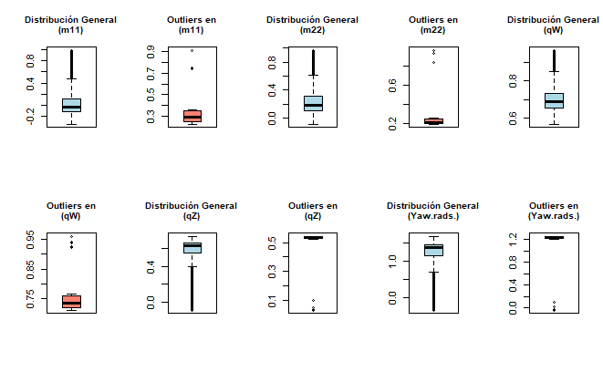

```r
# 4. Comparar distribuciones con el resto del dataset
# Configurar el layout para mostrar 5 pares de gráficos
par(mfrow = c(2, 5))  # 2 filas, 5 columnas

# Ajustar tamaño de título a 12
cex_title <- 0.9  # Factor de ajuste para el tamaño del título

# Variables del estudio
variables_estudio <- c("m11", "m22", "qW", "qZ", "Yaw.rads.", "accelUserX.g.", "magX.µT.", "magY.µT.", "magZ.µT.")

# Bucle para generar gráficos para cada variable
for (var in variables_estudio) {
  # Comparar distribución general
  boxplot(data_analysis[[var]],
          main = paste("Distribución General\n(", var, ")", sep = ""),
          col = "lightblue",
          cex.main = cex_title)

  # Comparar distribución de outliers
  boxplot(outlier_data[[var]],
          main = paste("Outliers en\n(", var, ")", sep = ""),
          col = "salmon",
          cex.main = cex_title)
}
```

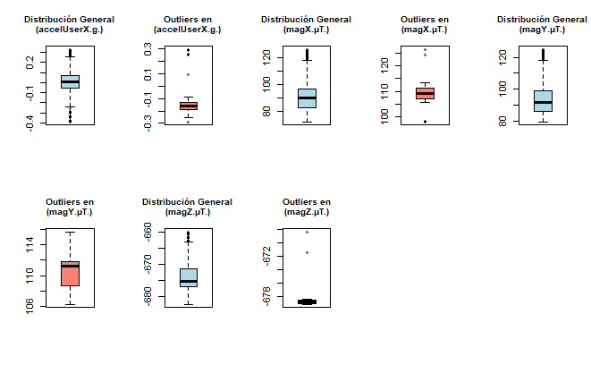

```r
# Resetear el layout
par(mfrow = c(1, 1))
```

```r
# 5. Inspeccionar registros adicionales
head(outlier_data[, c("Timestamp", "ActivityType", "gyroZ.rad.s.", "gyroY.rad.s.")])
```

|  | Timestamp | ActivityType | gyroZ.rad.s. | gyroY.rad.s. |
| --- | --- | --- | --- | --- |
| 200 | 2020-01-29 00:13:29 | Walking | 0.2834 | 0.6055 |
| 201 | 2020-01-29 00:13:29 | Walking | 0.3036 | 0.4124 |
| 202 | 2020-01-29 00:13:29 | Walking | 0.2449 | 0.1010 |
| 203 | 2020-01-29 00:13:29 | Walking | 0.2154 | 0.0259 |
| 204 | 2020-01-29 00:13:29 | Walking | 0.0909 | 0.3999 |
| 205 | 2020-01-29 00:13:29 | Walking | 0.0668 | 0.4932 |

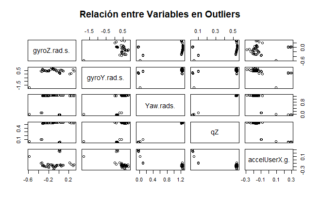

```r
# 6. Relación entre variables seleccionadas en los outliers
pairs(outlier_data[, c("gyroZ.rad.s.", "gyroY.rad.s.", "Yaw.rads.", "qZ", "accelUserX.g.")],
      main = "Relación entre Variables en Outliers")
```

```r
# 7. Agregar una columna de decisión manual para cada outlier
outlier_data <- outlier_data %>%
  mutate(decision = ifelse(gyroZ.rad.s. > 15 & gyroY.rad.s. > 15, "Conservar", "Revisar"))

# Mostrar dataset con decisiones
View(outlier_data)

# 8. Incorporar las decisiones al dataset original
data_analysis$outlier_review <- "No Outlier"
data_analysis$outlier_review[outlier_indices] <- outlier_data$decision

# 9. Resumen de las decisiones tomadas
table(data_analysis$outlier_review)
```

```
No Outlier    Revisar
      4930         46
```

### **Análisis Manual de Outliers**

1. **Identificación Multivariada:**
   - Se detectaron **46 observaciones** como outliers significativos mediante la distancia de Mahalanobis (clásica y robusta).
   - Estas observaciones presentan combinaciones extremas en variables como `m11`, `m22`, `qW`, `qZ`, `Yaw.rads.`, `accelUserX.g.`, y los campos magnéticos (`magX.µT.`, `magY.µT.`, `magZ.µT.`).
2. **Inspección Visual:**
   - Los **boxplots** muestran cómo los outliers tienen distribuciones específicas, separadas del comportamiento general del dataset.
   - En el **pairs plot**, los outliers multivariantes se agrupan en regiones específicas, destacando interacciones dinámicas entre aceleraciones, giroscopios y orientación.
3. **Observaciones Relevantes:**
   - Los outliers podrían representar:
     - **Eventos reales**: Cambios en dirección, giros bruscos o movimientos atípicos.
     - **Errores de medición**: Especialmente en los magnetómetros y cuaterniones.

### Próximos Pasos

Para mitigar la influencia de los valores extremos y prepararlos para análisis posteriores, se sugiere aplicar transformaciones específicas como **winsorización** o **transformación logarítmica**, seguidas por un escalado para normalizar las variables.

# 5. Pruebas de Normalidad

Evaluar si las variables numéricas siguen una distribución normal es un paso clave para seleccionar las técnicas estadísticas y de modelado más adecuadas. Esto permite asegurar que los supuestos subyacentes de ciertos métodos estadísticos, como pruebas paramétricas o modelos lineales, se cumplan correctamente.

**Hipótesis:**

- **Nula (H₀):** Los datos tienen una distribución normal.
- **Alternativa (H₁):** Los datos no tienen una distribución normal.

Se utilizarán pruebas estadísticas, como **Shapiro-Wilk** o **Kolmogorov-Smirnov**, para contrastar estas hipótesis y determinar si los datos pueden considerarse normalmente distribuidos.

```r
# Verificar si hay variables numéricas restantes después del filtrado
if (ncol(num_data) > 0) {
  cat("### Pruebas de Normalidad con Interpretación\n")

  # Crear una lista para almacenar resultados
  normality_interpretation <- list()

  # Iterar por cada columna numérica
  for (variable in names(num_data)) {
    # Realizar el test de Shapiro-Wilk
    shapiro_test <- shapiro.test(num_data[[variable]])

    # Evaluar el resultado
    if (shapiro_test$p.value > 0.05) {
      interpretation <- paste(
        "La variable", variable,
        "tiene un p-value =", round(shapiro_test$p.value, 4),
        "- Se acepta la hipótesis nula, la muestra tiene una distribución normal (Probablemente Gaussiana).\n"
      )
    } else {
      interpretation <- paste(
        "La variable", variable,
        "tiene un p-value =", round(shapiro_test$p.value, 4),
        "- Se rechaza la hipótesis nula, la muestra no tiene una distribución normal (Probablemente no Gaussiana).\n"
      )
    }

    # Agregar resultado a la lista
    normality_interpretation[[variable]] <- interpretation
  }

  # Imprimir resultados para cada variable
  for (result in normality_interpretation) {
    cat(result)
    cat("------------------------------------------------------------\n")
  }
} else {
  cat("No hay variables numéricas en el dataset después de filtrar.\n")
}
```

[output not shown]

#### **Resultados:**

# **6. Análisis de Asimetría, Curtosis y Varianza**

Este análisis ayuda a identificar variables con distribuciones sesgadas, colas largas o alta variabilidad. Esto es útil para detectar patrones y posibles transformaciones.

```r
if (ncol(num_data) > 0) {
  cat("### Análisis de Asimetría, Curtosis y Varianza")

  # Calcular asimetría, curtosis y varianza
  skew_kurt_var <- num_data %>%
    summarise(across(everything(), list(
      skewness = ~ skewness(.x, na.rm = TRUE),
      kurtosis = ~ kurtosis(.x, na.rm = TRUE),
      variance = ~ var(.x, na.rm = TRUE)
    )))

  # Convertir resultados a formato largo
  skew_kurt_var_long <- skew_kurt_var %>%
    pivot_longer(cols = everything(), names_to = c("Variable", "Metric"), names_sep = "_") %>%
    pivot_wider(names_from = "Metric", values_from = "value")

  # Renombrar las columnas para mayor claridad
  colnames(skew_kurt_var_long) <- c("Variable", "Asimetría (Skewness)", "Curtosis (Kurtosis)", "Varianza")

  # Mostrar la tabla
  print(skew_kurt_var_long)
} else {
  cat("No hay variables numéricas en el dataset.\n")
}
```

```
### Análisis de Asimetría, Curtosis y Varianza
```

| Variable | Asimetría (Skewness) | Curtosis (Kurtosis) | Varianza |
| --- | --- | --- | --- |
| accelX.g. | 0.01003475 | 2.043390 | 3.746935e-02 |
| accelY.g. | 0.14499471 | 3.331289 | 2.559548e-02 |
| accelZ.g. | -0.16374587 | 3.905251 | 3.232588e-02 |
| accelUserX.g. | 0.29786123 | 3.570804 | 8.851225e-03 |
| accelUserY.g. | 0.43662898 | 4.059642 | 1.157719e-02 |
| accelUserZ.g. | 0.15353821 | 4.145862 | 2.614669e-02 |
| gyroX.rad.s. | -0.40361182 | 2.195643 | 4.882985e-01 |
| gyroY.rad.s. | -0.69585381 | 3.409713 | 1.833952e+00 |
| gyroZ.rad.s. | 0.18591122 | 2.784844 | 3.667503e-01 |
| Roll.rads. | 0.12116617 | 2.677907 | 3.050990e-02 |

[output cut: 23 more lines]

### **Análisis de Asimetría, Curtosis y Varianza**

1. **Asimetría (Skewness):**
   - La mayoría de las variables presentan valores de asimetría cercanos a cero, indicando distribuciones aproximadamente simétricas. Sin embargo, algunas variables como `m12` (-1.726) y `m22` (1.677) tienen distribuciones moderadamente sesgadas.
   - Las variables con alta asimetría, como `m12` y `qY` (1.434), sugieren la presencia de valores extremos o concentraciones en un extremo de la distribución.
2. **Curtosis:**
   - Variables como `m12` (4.748) y `qZ` (4.921) muestran curtosis elevada, indicando colas más pesadas y valores atípicos. Esto refuerza la necesidad de un análisis profundo para comprender la relevancia de estos outliers.
   - En contraste, algunas variables tienen curtosis cercana a 3 (normal), como `Pitch.rads.` (3.404), lo que sugiere distribuciones bien comportadas.
3. **Varianza:**
   - Las variables relacionadas con campos magnéticos (`magX.µT.`, `magY.µT.`, `magZ.µT.`) tienen alta varianza, reflejando sensibilidad a condiciones externas. Esto las hace relevantes para capturar cambios dinámicos.
   - Las variables con baja varianza, como `calMagX.µT.` (0.81), podrían tener menor impacto predictivo en modelos relacionados con actividad.

# **7**. Análisis de Correlaciones

Las correlaciones entre variables numéricas son esenciales para identificar redundancias o relaciones útiles para el modelado.

```r
library(knitr)      # Para formatear tablas
library(kableExtra) # Para mejorar la presentación

# Verificar si hay variables numéricas
if (ncol(num_data) > 0) {
  # Filtrar dinámicamente las variables numéricas (descartando automáticamente no numéricas)
  num_data_filtered <- num_data %>%
    select(where(is.numeric))

  # Comprobar que hay más de una variable numérica para calcular correlación
  if (ncol(num_data_filtered) > 1) {
    # Calcular la matriz de correlación
    cor_matrix <- cor(num_data_filtered, use = "complete.obs")

    # Redondear para mejor visualización
    cor_matrix_rounded <- round(cor_matrix, 2)

    # Imprimir la matriz de correlación en la consola
    print("### Matriz de Correlación (Variables Numéricas)")
    print(cor_matrix_rounded)

    # Generar una tabla con knitr::kable para visualización más ordenada
    library(knitr)
    kable(cor_matrix_rounded, caption = "Tabla de Correlaciones (Solo Variables Numéricas)")
  } else {
    cat("No hay suficientes variables numéricas para calcular una matriz de correlación.\n")
  }
} else {
  cat("No hay variables numéricas en el dataset.\n")
}
```

```
[1] "### Matriz de Correlación (Variables Numéricas)"
                         accelX.g. accelY.g. accelZ.g. accelUserX.g. accelUserY.g. accelUserZ.g. gyroX.rad.s. gyroY.rad.s. gyroZ.rad.s. Roll.rads. Pitch.rads. Yaw.rads.   m11   m12   m13   m21
accelX.g.                     1.00      0.63     -0.14          0.58          0.04          0.00         0.27        -0.10        -0.17       0.86       -0.69     -0.14  0.22  0.12 -0.88  0.24
accelY.g.                     0.63      1.00     -0.22          0.15          0.55         -0.26         0.18        -0.04        -0.21       0.59       -0.75     -0.09  0.12  0.14 -0.68  0.20
accelZ.g.                    -0.14     -0.22      1.00         -0.12         -0.55          0.92         0.05         0.08        -0.01      -0.17       -0.20      0.06 -0.11  0.10  0.09 -0.04
accelUserX.g.                 0.58      0.15     -0.12          1.00          0.10         -0.11         0.32        -0.40        -0.34       0.12       -0.10      0.08 -0.08  0.13 -0.13 -0.06
accelUserY.g.                 0.04      0.55     -0.55          0.10          1.00         -0.58         0.25        -0.25        -0.49       0.02        0.14     -0.01  0.04 -0.08  0.01  0.01
accelUserZ.g.                 0.00     -0.26      0.92         -0.11         -0.58          1.00         0.11         0.08        -0.04       0.04       -0.15      0.00 -0.02  0.04 -0.06  0.02
gyroX.rad.s.                  0.27      0.18      0.05          0.32          0.25          0.11         1.00        -0.69        -0.69       0.17       -0.02      0.04  0.01  0.06 -0.15 -0.03
gyroY.rad.s.                 -0.10     -0.04      0.08         -0.40         -0.25          0.08        -0.69         1.00         0.61       0.09       -0.14     -0.01  0.00  0.01 -0.10  0.04
gyroZ.rad.s.                 -0.17     -0.21     -0.01         -0.34         -0.49         -0.04        -0.69         0.61         1.00      -0.04       -0.13     -0.01 -0.02  0.01  0.01  0.03
Roll.rads.                    0.86      0.59     -0.17          0.12          0.02          0.04         0.17         0.09        -0.04       1.00       -0.66     -0.23  0.35  0.03 -0.98  0.32
Pitch.rads.                  -0.69     -0.75     -0.20         -0.10          0.14         -0.15        -0.02        -0.14        -0.13      -0.66        1.00      0.10 -0.11 -0.23  0.79 -0.23
Yaw.rads.                    -0.14     -0.09      0.06          0.08         -0.01          0.00         0.04        -0.01        -0.01      -0.23        0.10      1.00 -0.98  0.90  0.23 -0.98
m11                           0.22      0.12     -0.11         -0.08          0.04         -0.02         0.01         0.00        -0.02       0.35       -0.11     -0.98  1.00 -0.85 -0.32  0.94
m12                           0.12      0.14      0.10          0.13         -0.08          0.04         0.06         0.01         0.01       0.03       -0.23      0.90 -0.85  1.00 -0.07 -0.88
m13                          -0.88     -0.68      0.09         -0.13          0.01         -0.06        -0.15        -0.10         0.01      -0.98        0.79      0.23 -0.32 -0.07  1.00 -0.32
m21                           0.24      0.20     -0.04         -0.06          0.01          0.02        -0.03         0.04         0.03       0.32       -0.23     -0.98  0.94 -0.88 -0.32  1.00
m22                           0.12      0.05     -0.08         -0.09          0.01         -0.01        -0.04         0.00         0.00       0.22       -0.05     -0.97  0.97 -0.84 -0.20  0.92
m23                          -0.71     -0.75     -0.18         -0.11          0.14         -0.15        -0.02        -0.15        -0.13      -0.69        1.00      0.10 -0.11 -0.23  0.81 -0.23
m31                          -0.43     -0.47     -0.21         -0.11          0.18         -0.13         0.01        -0.09        -0.11      -0.35        0.71     -0.04  0.04 -0.42  0.46 -0.02
m32                           0.51      0.38     -0.09          0.00          0.00          0.02         0.04         0.05         0.01       0.62       -0.44     -0.90  0.92 -0.68 -0.62  0.92
m33                           0.37     -0.04     -0.44          0.09          0.10         -0.07         0.15        -0.05        -0.11       0.55        0.19     -0.18  0.26 -0.17 -0.40  0.16
qX                           -0.70     -0.60     -0.01         -0.06          0.06         -0.08        -0.05        -0.10        -0.05      -0.77        0.76      0.68 -0.70  0.36  0.82 -0.75
qY                            0.47      0.20     -0.29          0.00          0.13         -0.06         0.13         0.00        -0.10       0.66       -0.12     -0.69  0.78 -0.64 -0.58  0.69
qZ                           -0.13     -0.07      0.08          0.09         -0.03          0.01         0.03        -0.01         0.00      -0.23        0.06      1.00 -0.97  0.93  0.21 -0.98
```

[output cut: 38 more lines]

Tabla de Correlaciones (Solo Variables Numéricas)

|  | accelX.g. | accelY.g. | accelZ.g. | accelUserX.g. | accelUserY.g. | accelUserZ.g. | gyroX.rad.s. | gyroY.rad.s. | gyroZ.rad.s. | Roll.rads. | Pitch.rads. | Yaw.rads. | m11 | m12 | m13 | m21 | m22 | m23 | m31 | m32 | m33 | qX | qY | qZ | qW | Pressure.kilopascals. | RelativeAltitude.meters. | magX.µT. | magY.µT. | … |
| --- | --- | --- | --- | --- | --- | --- | --- | --- | --- | --- | --- | --- | --- | --- | --- | --- | --- | --- | --- | --- | --- | --- | --- | --- | --- | --- | --- | --- | --- | --- |
| accelX.g. | 1.00 | 0.63 | -0.14 | 0.58 | 0.04 | 0.00 | 0.27 | -0.10 | -0.17 | 0.86 | -0.69 | -0.14 | 0.22 | 0.12 | -0.88 | 0.24 | 0.12 | -0.71 | -0.43 | 0.51 | 0.37 | -0.70 | 0.47 | -0.13 | 0.22 | 0.21 | -0.21 | 0.60 | 0.42 | … |
| accelY.g. | 0.63 | 1.00 | -0.22 | 0.15 | 0.55 | -0.26 | 0.18 | -0.04 | -0.21 | 0.59 | -0.75 | -0.09 | 0.12 | 0.14 | -0.68 | 0.20 | 0.05 | -0.75 | -0.47 | 0.38 | -0.04 | -0.60 | 0.20 | -0.07 | 0.09 | 0.24 | -0.24 | 0.39 | 0.43 | … |
| accelZ.g. | -0.14 | -0.22 | 1.00 | -0.12 | -0.55 | 0.92 | 0.05 | 0.08 | -0.01 | -0.17 | -0.20 | 0.06 | -0.11 | 0.10 | 0.09 | -0.04 | -0.08 | -0.18 | -0.21 | -0.09 | -0.44 | -0.01 | -0.29 | 0.08 | -0.14 | 0.01 | -0.01 | -0.14 | 0.10 | … |
| accelUserX.g. | 0.58 | 0.15 | -0.12 | 1.00 | 0.10 | -0.11 | 0.32 | -0.40 | -0.34 | 0.12 | -0.10 | 0.08 | -0.08 | 0.13 | -0.13 | -0.06 | -0.09 | -0.11 | -0.11 | 0.00 | 0.09 | -0.06 | 0.00 | 0.09 | -0.06 | -0.07 | 0.07 | 0.06 | -0.04 | … |
| accelUserY.g. | 0.04 | 0.55 | -0.55 | 0.10 | 1.00 | -0.58 | 0.25 | -0.25 | -0.49 | 0.02 | 0.14 | -0.01 | 0.04 | -0.08 | 0.01 | 0.01 | 0.01 | 0.14 | 0.18 | 0.00 | 0.10 | 0.06 | 0.13 | -0.03 | 0.03 | 0.01 | -0.01 | 0.02 | -0.06 | … |
| accelUserZ.g. | 0.00 | -0.26 | 0.92 | -0.11 | -0.58 | 1.00 | 0.11 | 0.08 | -0.04 | 0.04 | -0.15 | 0.00 | -0.02 | 0.04 | -0.06 | 0.02 | -0.01 | -0.15 | -0.13 | 0.02 | -0.07 | -0.08 | -0.06 | 0.01 | -0.02 | -0.01 | 0.01 | 0.02 | 0.10 | … |
| gyroX.rad.s. | 0.27 | 0.18 | 0.05 | 0.32 | 0.25 | 0.11 | 1.00 | -0.69 | -0.69 | 0.17 | -0.02 | 0.04 | 0.01 | 0.06 | -0.15 | -0.03 | -0.04 | -0.02 | 0.01 | 0.04 | 0.15 | -0.05 | 0.13 | 0.03 | 0.01 | 0.02 | -0.02 | 0.14 | 0.01 | … |
| gyroY.rad.s. | -0.10 | -0.04 | 0.08 | -0.40 | -0.25 | 0.08 | -0.69 | 1.00 | 0.61 | 0.09 | -0.14 | -0.01 | 0.00 | 0.01 | -0.10 | 0.04 | 0.00 | -0.15 | -0.09 | 0.05 | -0.05 | -0.10 | 0.00 | -0.01 | 0.00 | -0.01 | 0.01 | -0.05 | 0.09 | … |
| gyroZ.rad.s. | -0.17 | -0.21 | -0.01 | -0.34 | -0.49 | -0.04 | -0.69 | 0.61 | 1.00 | -0.04 | -0.13 | -0.01 | -0.02 | 0.01 | 0.01 | 0.03 | 0.00 | -0.13 | -0.11 | 0.01 | -0.11 | -0.05 | -0.10 | 0.00 | -0.02 | 0.00 | 0.00 | -0.06 | 0.06 | … |
| Roll.rads. | 0.86 | 0.59 | -0.17 | 0.12 | 0.02 | 0.04 | 0.17 | 0.09 | -0.04 | 1.00 | -0.66 | -0.23 | 0.35 | 0.03 | -0.98 | 0.32 | 0.22 | -0.69 | -0.35 | 0.62 | 0.55 | -0.77 | 0.66 | -0.23 | 0.35 | 0.27 | -0.27 | 0.72 | 0.47 | … |
| Pitch.rads. | -0.69 | -0.75 | -0.20 | -0.10 | 0.14 | -0.15 | -0.02 | -0.14 | -0.13 | -0.66 | 1.00 | 0.10 | -0.11 | -0.23 | 0.79 | -0.23 | -0.05 | 1.00 | 0.71 | -0.44 | 0.19 | 0.76 | -0.12 | 0.06 | -0.08 | -0.30 | 0.30 | -0.43 | -0.56 | … |
| Yaw.rads. | -0.14 | -0.09 | 0.06 | 0.08 | -0.01 | 0.00 | 0.04 | -0.01 | -0.01 | -0.23 | 0.10 | 1.00 | -0.98 | 0.90 | 0.23 | -0.98 | -0.97 | 0.10 | -0.04 | -0.90 | -0.18 | 0.68 | -0.69 | 1.00 | -0.96 | -0.78 | 0.78 | -0.82 | -0.86 | … |
| m11 | 0.22 | 0.12 | -0.11 | -0.08 | 0.04 | -0.02 | 0.01 | 0.00 | -0.02 | 0.35 | -0.11 | -0.98 | 1.00 | -0.85 | -0.32 | 0.94 | 0.97 | -0.11 | 0.04 | 0.92 | 0.26 | -0.70 | 0.78 | -0.97 | 0.99 | 0.80 | -0.80 | 0.89 | 0.82 | … |
| m12 | 0.12 | 0.14 | 0.10 | 0.13 | -0.08 | 0.04 | 0.06 | 0.01 | 0.01 | 0.03 | -0.23 | 0.90 | -0.85 | 1.00 | -0.07 | -0.88 | -0.84 | -0.23 | -0.42 | -0.68 | -0.17 | 0.36 | -0.64 | 0.93 | -0.82 | -0.56 | 0.56 | -0.59 | -0.65 | … |
| m13 | -0.88 | -0.68 | 0.09 | -0.13 | 0.01 | -0.06 | -0.15 | -0.10 | 0.01 | -0.98 | 0.79 | 0.23 | -0.32 | -0.07 | 1.00 | -0.32 | -0.20 | 0.81 | 0.46 | -0.62 | -0.40 | 0.82 | -0.58 | 0.21 | -0.31 | -0.31 | 0.31 | -0.70 | -0.53 | … |
| m21 | 0.24 | 0.20 | -0.04 | -0.06 | 0.01 | 0.02 | -0.03 | 0.04 | 0.03 | 0.32 | -0.23 | -0.98 | 0.94 | -0.88 | -0.32 | 1.00 | 0.92 | -0.23 | -0.02 | 0.92 | 0.16 | -0.75 | 0.69 | -0.98 | 0.91 | 0.74 | -0.74 | 0.83 | 0.92 | … |
| m22 | 0.12 | 0.05 | -0.08 | -0.09 | 0.01 | -0.01 | -0.04 | 0.00 | 0.00 | 0.22 | -0.05 | -0.97 | 0.97 | -0.84 | -0.20 | 0.92 | 1.00 | -0.05 | -0.03 | 0.86 | 0.20 | -0.64 | 0.64 | -0.96 | 0.98 | 0.83 | -0.83 | 0.81 | 0.79 | … |
| m23 | -0.71 | -0.75 | -0.18 | -0.11 | 0.14 | -0.15 | -0.02 | -0.15 | -0.13 | -0.69 | 1.00 | 0.10 | -0.11 | -0.23 | 0.81 | -0.23 | -0.05 | 1.00 | 0.70 | -0.45 | 0.13 | 0.76 | -0.14 | 0.06 | -0.08 | -0.28 | 0.28 | -0.44 | -0.56 | … |
| m31 | -0.43 | -0.47 | -0.21 | -0.11 | 0.18 | -0.13 | 0.01 | -0.09 | -0.11 | -0.35 | 0.71 | -0.04 | 0.04 | -0.42 | 0.46 | -0.02 | -0.03 | 0.70 | 1.00 | -0.18 | 0.24 | 0.49 | 0.30 | -0.10 | 0.00 | -0.29 | 0.29 | -0.18 | -0.28 | … |
| m32 | 0.51 | 0.38 | -0.09 | 0.00 | 0.00 | 0.02 | 0.04 | 0.05 | 0.01 | 0.62 | -0.44 | -0.90 | 0.92 | -0.68 | -0.62 | 0.92 | 0.86 | -0.45 | -0.18 | 1.00 | 0.29 | -0.91 | 0.80 | -0.89 | 0.90 | 0.76 | -0.76 | 0.97 | 0.93 | … |
| m33 | 0.37 | -0.04 | -0.44 | 0.09 | 0.10 | -0.07 | 0.15 | -0.05 | -0.11 | 0.55 | 0.19 | -0.18 | 0.26 | -0.17 | -0.40 | 0.16 | 0.20 | 0.13 | 0.24 | 0.29 | 1.00 | -0.18 | 0.64 | -0.19 | 0.32 | -0.04 | 0.04 | 0.41 | -0.02 | … |
| qX | -0.70 | -0.60 | -0.01 | -0.06 | 0.06 | -0.08 | -0.05 | -0.10 | -0.05 | -0.77 | 0.76 | 0.68 | -0.70 | 0.36 | 0.82 | -0.75 | -0.64 | 0.76 | 0.49 | -0.91 | -0.18 | 1.00 | -0.62 | 0.65 | -0.69 | -0.68 | 0.68 | -0.89 | -0.90 | … |
| qY | 0.47 | 0.20 | -0.29 | 0.00 | 0.13 | -0.06 | 0.13 | 0.00 | -0.10 | 0.66 | -0.12 | -0.69 | 0.78 | -0.64 | -0.58 | 0.69 | 0.64 | -0.14 | 0.30 | 0.80 | 0.64 | -0.62 | 1.00 | -0.71 | 0.76 | 0.45 | -0.45 | 0.85 | 0.59 | … |
| qZ | -0.13 | -0.07 | 0.08 | 0.09 | -0.03 | 0.01 | 0.03 | -0.01 | 0.00 | -0.23 | 0.06 | 1.00 | -0.97 | 0.93 | 0.21 | -0.98 | -0.96 | 0.06 | -0.10 | -0.89 | -0.19 | 0.65 | -0.71 | 1.00 | -0.96 | -0.76 | 0.76 | -0.81 | -0.84 | … |
| qW | 0.22 | 0.09 | -0.14 | -0.06 | 0.03 | -0.02 | 0.01 | 0.00 | -0.02 | 0.35 | -0.08 | -0.96 | 0.99 | -0.82 | -0.31 | 0.91 | 0.98 | -0.08 | 0.00 | 0.90 | 0.32 | -0.69 | 0.76 | -0.96 | 1.00 | 0.81 | -0.81 | 0.88 | 0.79 | … |
| Pressure.kilopascals. | 0.21 | 0.24 | 0.01 | -0.07 | 0.01 | -0.01 | 0.02 | -0.01 | 0.00 | 0.27 | -0.30 | -0.78 | 0.80 | -0.56 | -0.31 | 0.74 | 0.83 | -0.28 | -0.29 | 0.76 | -0.04 | -0.68 | 0.45 | -0.76 | 0.81 | 1.00 | -1.00 | 0.73 | 0.75 | … |
| RelativeAltitude.meters. | -0.21 | -0.24 | -0.01 | 0.07 | -0.01 | 0.01 | -0.02 | 0.01 | 0.00 | -0.27 | 0.30 | 0.78 | -0.80 | 0.56 | 0.31 | -0.74 | -0.83 | 0.28 | 0.29 | -0.76 | 0.04 | 0.68 | -0.45 | 0.76 | -0.81 | -1.00 | 1.00 | -0.73 | -0.75 | … |
| magX.µT. | 0.60 | 0.39 | -0.14 | 0.06 | 0.02 | 0.02 | 0.14 | -0.05 | -0.06 | 0.72 | -0.43 | -0.82 | 0.89 | -0.59 | -0.70 | 0.83 | 0.81 | -0.44 | -0.18 | 0.97 | 0.41 | -0.89 | 0.85 | -0.81 | 0.88 | 0.73 | -0.73 | 1.00 | 0.84 | … |
| magY.µT. | 0.42 | 0.43 | 0.10 | -0.04 | -0.06 | 0.10 | 0.01 | 0.09 | 0.06 | 0.47 | -0.56 | -0.86 | 0.82 | -0.65 | -0.53 | 0.92 | 0.79 | -0.56 | -0.28 | 0.93 | -0.02 | -0.90 | 0.59 | -0.84 | 0.79 | 0.75 | -0.75 | 0.84 | 1.00 | … |
| magZ.µT. | -0.56 | -0.52 | 0.14 | -0.15 | -0.13 | 0.03 | -0.24 | 0.20 | 0.22 | -0.58 | 0.50 | 0.06 | -0.12 | -0.27 | 0.60 | -0.10 | -0.16 | 0.52 | 0.74 | -0.31 | -0.30 | 0.51 | -0.08 | 0.02 | -0.19 | -0.30 | 0.30 | -0.39 | -0.22 | … |
| calMagX.µT. | 0.60 | 0.39 | -0.14 | 0.04 | 0.01 | 0.02 | 0.09 | 0.02 | -0.02 | 0.73 | -0.45 | -0.82 | 0.89 | -0.59 | -0.71 | 0.84 | 0.81 | -0.46 | -0.19 | 0.97 | 0.41 | -0.90 | 0.85 | -0.81 | 0.88 | 0.73 | -0.73 | 1.00 | 0.85 | … |
| calMagY.µT. | 0.41 | 0.43 | 0.10 | -0.04 | -0.06 | 0.10 | -0.03 | 0.11 | 0.09 | 0.46 | -0.56 | -0.86 | 0.82 | -0.66 | -0.52 | 0.92 | 0.79 | -0.56 | -0.28 | 0.92 | -0.03 | -0.90 | 0.58 | -0.84 | 0.78 | 0.75 | -0.75 | 0.83 | 1.00 | … |
| calMagZ.µT. | -0.56 | -0.51 | 0.15 | -0.11 | -0.08 | 0.03 | -0.16 | 0.12 | 0.11 | -0.61 | 0.53 | 0.06 | -0.12 | -0.29 | 0.63 | -0.10 | -0.16 | 0.54 | 0.76 | -0.32 | -0.33 | 0.53 | -0.09 | 0.02 | -0.19 | -0.30 | 0.30 | -0.40 | -0.23 | … |

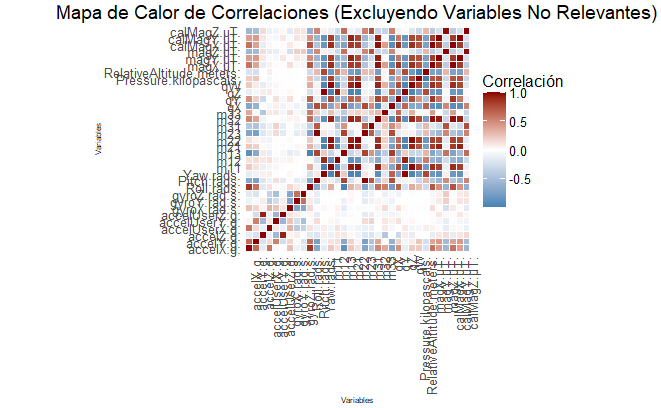

```r
library(ggplot2)
library(reshape2)

# Convertir la matriz en formato largo
corr_melted <- melt(cor_matrix)

# Crear el heatmap
ggplot(corr_melted, aes(x = Var1, y = Var2, fill = value)) +
  geom_tile(color = "white") +
  scale_fill_gradient2(low = "steelblue", high = "darkred", mid = "white", midpoint = 0, name = "Correlación") +
  theme_minimal(base_size = 6) +  # Aumentar el tamaño del texto
  theme(
    axis.text.x = element_text(angle = 90, hjust = 1, size = 10),
    axis.text.y = element_text(size = 10),
    plot.title = element_text(hjust = 0.5, size = 14),
    legend.text = element_text(size = 10),
    legend.title = element_text(size = 12)
  ) +
  labs(
    title = "Mapa de Calor de Correlaciones (Excluyendo Variables No Relevantes)",
    x = "Variables",
    y = "Variables"
  ) +
  coord_fixed()
```

### **Analisisis de Colinealidad**

A partir del análisis de correlaciones realizado en el dataset, se ha identificado que algunas variables presentan relaciones fuertes entre sí, lo que sugiere la presencia de **colinealidad**. Este fenómeno ocurre cuando dos o más variables predictoras están altamente correlacionadas, lo que puede afectar negativamente la estabilidad y la interpretabilidad del modelo.

Dado que el dataset incluye múltiples mediciones de aceleración, velocidad angular y variables derivadas de sensores, es importante realizar un análisis de colinealidad para:

1. **Identificar variables redundantes:** Detectar aquellas características que contienen información duplicada o muy similar, lo que puede generar sobreajuste en modelos predictivos.
2. **Reducir la dimensionalidad del problema:** Determinar si es necesario eliminar o transformar variables para mejorar la eficiencia del modelo.
3. **Evitar problemas en algoritmos sensibles a la colinealidad:** Modelos como la regresión logística, SVM y redes neuronales pueden verse afectados por la presencia de colinealidad, lo que puede distorsionar la estimación de coeficientes y afectar la capacidad de generalización.

```r
library(dplyr)

# Verificar que el dataset existe
if (exists("data")) {
  # Filtrar las variables numéricas y eliminar la variable dependiente (ActivityType)
  num_data_filtered <- data %>%
    select(where(is.numeric)) %>%
    mutate(dummy_target = runif(nrow(.), 0, 1)) # Crear una variable dummy temporal

  # Validar si hay suficientes variables para calcular el modelo
  if (ncol(num_data_filtered) > 1) {
    # Crear un modelo de regresión con las variables predictoras
    vif_model <- lm(dummy_target ~ ., data = num_data_filtered)

    # Calcular los valores de VIF
    vif_values <- vif(vif_model)

    # Imprimir los valores de VIF
    print("### Factores de Inflación de Varianza (VIF)")
    print(vif_values)

    # Identificar variables con alta colinealidad (VIF > 10 como umbral común)
    high_vif <- vif_values[vif_values > 10]
    if (length(high_vif) > 0) {
      cat("\nVariables con alta colinealidad (VIF > 10):\n")
      print(high_vif)
    } else {
      cat("\nNo se encontraron variables con alta colinealidad (VIF <= 10).\n")
    }
  } else {
    cat("No hay suficientes variables numéricas para calcular el VIF.\n")
  }
} else {
  cat("El dataset 'data' no existe en el entorno.\n")
}
```

```
[1] "### Factores de Inflación de Varianza (VIF)"
               accelX.g.                accelY.g.                accelZ.g.            accelUserX.g.            accelUserY.g.            accelUserZ.g.             gyroX.rad.s.
            3.988330e+02             3.258699e+02             2.027085e+02             9.398610e+01             1.487743e+02             1.653032e+02             4.909243e+00
            gyroY.rad.s.             gyroZ.rad.s.               Roll.rads.              Pitch.rads.                Yaw.rads.                      m11                      m12
            8.003701e+00             4.302456e+00             2.011479e+04             1.699025e+04             1.979744e+05             1.967135e+04             8.335143e+03
                     m13                      m21                      m22                      m23                      m31                      m32                      m33
            5.095676e+03             1.415860e+04             7.897744e+03             1.048743e+04             2.681462e+03             4.658470e+03             1.475746e+03
                      qX                       qY                       qZ                       qW    Pressure.kilopascals. RelativeAltitude.meters.                 magX.µT.
            1.816894e+04             6.732494e+03             2.288064e+05             6.553003e+04             1.556779e+05             1.556633e+05             2.634977e+02
                magY.µT.                 magZ.µT.              calMagX.µT.              calMagY.µT.              calMagZ.µT.
            4.642306e+02             5.358073e+01             5.963232e+02             6.311950e+02             7.743884e+01

Variables con alta colinealidad (VIF > 10):
               accelX.g.                accelY.g.                accelZ.g.            accelUserX.g.            accelUserY.g.            accelUserZ.g.               Roll.rads.
               398.83301                325.86993                202.70850                 93.98610                148.77426                165.30316              20114.78758
             Pitch.rads.                Yaw.rads.                      m11                      m12                      m13                      m21                      m22
             16990.24746             197974.40068              19671.34870               8335.14326               5095.67587              14158.59778               7897.74368
                     m23                      m31                      m32                      m33                       qX                       qY                       qZ
             10487.43081               2681.46193               4658.47014               1475.74608              18168.93909               6732.49442             228806.37227
                      qW    Pressure.kilopascals. RelativeAltitude.meters.                 magX.µT.                 magY.µT.                 magZ.µT.              calMagX.µT.
             65530.03459             155677.88638             155663.32666                263.49772                464.23065                 53.58073                596.32316
             calMagY.µT.              calMagZ.µT.
               631.19500                 77.43884
```

### **Análisis de Factores de Inflación de Varianza (VIF)**

1. **Identificación de Variables con Alta Colinealidad (VIF > 10):**
   - Varias variables, como `m12`, `m22`, `qW`, `Pressure.kilopascals.`, `RelativeAltitude.meters.`, y las variables magnéticas (`magX.µT.`, `magY.µT.`, `calMagX.µT.`, `calMagY.µT.`), presentan valores de VIF significativamente altos. Esto indica una fuerte colinealidad con otras variables del conjunto de datos.
   - Variables relacionadas con la orientación (`qX`, `qY`, `qZ`) y matrices de rotación (`m11`, `m12`, `m21`, etc.) también muestran colinealidad extrema, lo que refuerza la hipótesis de redundancia en estas mediciones.
2. **Implicaciones de la Alta Colinealidad:**
   - Las variables con colinealidad extrema pueden inflar los errores estándar de los coeficientes en modelos de regresión, dificultando la interpretación y estabilidad del modelo.
   - La redundancia observada en matrices de rotación y cuaterniones sugiere que una parte significativa de estas variables puede ser reducida o transformada sin pérdida de información relevante.
3. **Estrategias Recomendadas:**
   - **Reducción de Dimensionalidad:** Aplicar técnicas como PCA (Análisis de Componentes Principales) para consolidar las variables colineales en componentes representativos.
   - **Eliminación de Variables:** Excluir aquellas con VIF extremadamente altos y bajo impacto dinámico, como `Pressure.kilopascals.` y `RelativeAltitude.meters.`, si no son esenciales para los objetivos del análisis.
   - **Normalización y Escalado:** Las variables magnéticas (`magX.µT.`, `magY.µT.`, `calMagX.µT.`, etc.) podrían beneficiarse de técnicas de normalización para controlar su impacto en modelos posteriores.

En resumen, los valores altos de VIF destacan la necesidad de manejar adecuadamente la colinealidad en este dataset, ya que afecta directamente la calidad de los modelos predictivos o explicativos que se puedan construir.

# **9.** Resumen y Conclusiones

### 9.1 Resumen del Análisis Realizado

#### Transformaciones y Limpieza

1. Se convirtió la variable `Timestamp` al formato `POSIXct` para un mejor manejo temporal.
2. No se aplicaron imputaciones a los datos, ya que no se identificaron valores faltantes en el dataset.
3. Se eliminaron variables redundantes y de baja comparabilidad con otros datasets (`Lat`, `Long`, `Speed.m.s.`, `TrueHeading`, `Alt.m.`, `HorizontalAccuracy.m.`, `VerticalAccuracy.m.`, `Course`), asegurando un enfoque en variables clave para el análisis de dinámicas.

#### Análisis Multivariante

1. **Identificación de Outliers Multivariantes**:
   - Se aplicaron distancias de Mahalanobis clásica y robusta para identificar outliers multivariantes.
   - Se detectaron **46 observaciones multivariantes atípicas**, las cuales fueron marcadas para revisión manual.
   - Las visualizaciones mostraron una distribución compacta de la mayoría de los datos y un grupo claro de outliers.
2. **Relaciones Entre Variables**:
   - Las relaciones entre variables seleccionadas (`gyroZ.rad.s.`, `gyroY.rad.s.`, `Yaw.rads.`, `qZ`, `accelUserX.g.`) reflejan patrones que podrían estar asociados a eventos específicos de la actividad de caminar.

### 9.2 Conclusiones

#### 1. **Detección y Manejo de Outliers**

El análisis de outliers ya incluyó una revisión manual detallada basada en distancias de Mahalanobis clásicas y robustas. Se identificaron 46 observaciones como outliers multivariantes, afectando principalmente a variables como `m11`, `m22`, `qW`, `qZ`, `Yaw.rads.`, `accelUserX.g.`, `magX.µT.`, `magY.µT.`, y `magZ.µT.`.

#### 2. **Análisis de Correlaciones**

Se detectaron altas correlaciones entre variables de orientación (`qX`, `qY`, `qZ`, `m11`, `m22`), lo que sugiere redundancia en la representación de estas dimensiones. Este hallazgo indica que estas variables pueden ser condensadas mediante técnicas de reducción de dimensionalidad, como PCA, o mediante la eliminación de las variables menos informativas para simplificar el modelo y evitar multicolinealidad.

#### 3. **Transformaciones Aplicadas y Recomendadas**

- **RobustScaler** es adecuado para variables con outliers significativos (`gyroZ.rad.s.`, `accelUserX.g.`).
- **Min-Max Scaling** puede ser aplicado a variables con rangos más controlados (`Pitch.rads.`, `Yaw.rads.`, `Pressure.kilopascals.`).

### 9.3 **Flujo de Transformación de Datos**

- Evaluar la aplicación de **winsorización o transformaciones logarítmicas** en variables con alta presencia de outliers, como `Yaw.rads.`, `gyroZ(rad/s)`, y `qZ`, para mejorar la estabilidad del modelo.
- Refinar la selección de variables para mitigar el efecto de la colinealidad alta en `qX`, `qY`, `qZ`, `qW`, y `m11 - m33`. Se evaluará la aplicación de **reducción de dimensionalidad mediante PCA** para conservar solo las variables más informativas. Alternativamente, si la colinealidad es excesiva (VIF > 1000), se considerará la eliminación de algunas de estas variables para evitar redundancia en el modelo.
- Implementar estrategias de escalado adaptadas al modelo final, usando **RobustScaler para datos con alta dispersión** y **Min-Max Scaling en variables con rangos controlados**.
- Desarrollar pruebas de validación del modelo considerando distintas combinaciones de transformación de datos y selección de variables para determinar el mejor rendimiento en la clasificación del tipo de transporte.

# 10. Descarga de dataset

```r
head(data)  # Primeras 6 filas
```

|  | Timestamp | accelX.g. | accelY.g. | accelZ.g. | accelUserX.g. | accelUserY.g. | accelUserZ.g. | gyroX.rad.s. | gyroY.rad.s. | gyroZ.rad.s. | Roll.rads. | Pitch.rads. | Yaw.rads. | m11 | m12 | m13 | m21 | m22 | m23 | m31 | m32 | m33 | qX | qY | qZ | qW | ActivityType | ActivityConfidence | Pressure.kilopascals. | … |
| --- | --- | --- | --- | --- | --- | --- | --- | --- | --- | --- | --- | --- | --- | --- | --- | --- | --- | --- | --- | --- | --- | --- | --- | --- | --- | --- | --- | --- | --- | --- |
| 1 | 2020-01-29 00:13:27 | -0.4829 | 0.8790 | -0.6400 | -0.0875 | 0.1564 | -0.0770 | 0.3705 | -0.4153 | -0.2858 | -0.6125 | -0.8165 | 1.0747 | 0.0209 | 0.9190 | 0.3937 | -0.6022 | 0.3259 | -0.7288 | -0.7981 | -0.2218 | 0.5603 | -0.1835 | -0.4315 | 0.5508 | 0.6905 | Walking | Med | 102.0587 | … |
| 2 | 2020-01-29 00:13:27 | -0.4851 | 0.8479 | -0.6653 | -0.0886 | 0.1263 | -0.0983 | 0.2513 | -0.2630 | -0.2587 | -0.6151 | -0.8133 | 1.0739 | 0.0207 | 0.9178 | 0.3965 | -0.6040 | 0.3275 | -0.7266 | -0.7967 | -0.2244 | 0.5612 | -0.1817 | -0.4318 | 0.5507 | 0.6909 | Walking | Med | 102.0587 | … |
| 3 | 2020-01-29 00:13:27 | -0.4865 | 0.8363 | -0.6807 | -0.0872 | 0.1130 | -0.1184 | 0.1528 | -0.1200 | -0.2161 | -0.6164 | -0.8110 | 1.0735 | 0.0210 | 0.9171 | 0.3982 | -0.6053 | 0.3286 | -0.7250 | -0.7957 | -0.2258 | 0.5620 | -0.1805 | -0.4317 | 0.5506 | 0.6913 | Walking | Med | 102.0587 | … |
| 4 | 2020-01-29 00:13:27 | -0.4975 | 0.8224 | -0.6734 | -0.0967 | 0.1024 | -0.1125 | 0.0942 | 0.0080 | -0.1635 | -0.6164 | -0.8094 | 1.0728 | 0.0222 | 0.9167 | 0.3989 | -0.6061 | 0.3296 | -0.7239 | -0.7950 | -0.2257 | 0.5630 | -0.1800 | -0.4314 | 0.5503 | 0.6919 | Walking | Med | 102.0587 | … |
| 5 | 2020-01-29 00:13:27 | -0.4963 | 0.7916 | -0.6615 | -0.0985 | 0.0767 | -0.1001 | 0.0504 | 0.0879 | -0.1231 | -0.6160 | -0.8083 | 1.0726 | 0.0229 | 0.9166 | 0.3991 | -0.6068 | 0.3300 | -0.7231 | -0.7945 | -0.2256 | 0.5638 | -0.1797 | -0.4311 | 0.5502 | 0.6922 | Walking | Med | 102.0587 | … |
| 6 | 2020-01-29 00:13:27 | -0.4834 | 0.7481 | -0.6498 | -0.0873 | 0.0336 | -0.0884 | 0.0079 | 0.0829 | -0.0981 | -0.6162 | -0.8076 | 1.0719 | 0.0237 | 0.9164 | 0.3995 | -0.6070 | 0.3307 | -0.7226 | -0.7943 | -0.2254 | 0.5641 | -0.1795 | -0.4310 | 0.5499 | 0.6926 | Walking | Med | 102.0587 | … |

```r
tail(data)  # Últimas 6 filas
```

|  | Timestamp | accelX.g. | accelY.g. | accelZ.g. | accelUserX.g. | accelUserY.g. | accelUserZ.g. | gyroX.rad.s. | gyroY.rad.s. | gyroZ.rad.s. | Roll.rads. | Pitch.rads. | Yaw.rads. | m11 | m12 | m13 | m21 | m22 | m23 | m31 | m32 | m33 | qX | qY | qZ | qW | ActivityType | ActivityConfidence | Pressure.kilopascals. | … |
| --- | --- | --- | --- | --- | --- | --- | --- | --- | --- | --- | --- | --- | --- | --- | --- | --- | --- | --- | --- | --- | --- | --- | --- | --- | --- | --- | --- | --- | --- | --- |
| 4971 | 2020-01-29 00:13:18 | -0.4337 | 0.6687 | -0.8763 | -0.1077 | 0.1103 | -0.0877 | -1.1626 | 1.9691 | -0.0118 | -0.3836 | -0.5820 | 1.5546 | -0.1906 | 0.9306 | 0.3126 | -0.8352 | 0.0136 | -0.5497 | -0.5158 | -0.3659 | 0.7747 | -0.0727 | -0.3277 | 0.6985 | 0.6320 | Walking | High | 102.0251 | … |
| 4972 | 2020-01-29 00:13:18 | -0.4567 | 0.7198 | -0.9571 | -0.1642 | 0.1503 | -0.1612 | -0.9366 | 2.2496 | -0.0530 | -0.3621 | -0.5892 | 1.5501 | -0.1775 | 0.9390 | 0.2945 | -0.8312 | 0.0172 | -0.5557 | -0.5269 | -0.3434 | 0.7775 | -0.0835 | -0.3230 | 0.6960 | 0.6358 | Walking | High | 102.0251 | … |
| 4973 | 2020-01-29 00:13:18 | -0.4230 | 0.8251 | -1.0913 | -0.1546 | 0.2409 | -0.2751 | -0.7455 | 2.5049 | -0.1217 | -0.3400 | -0.5948 | 1.5454 | -0.1629 | 0.9472 | 0.2762 | -0.8280 | 0.0211 | -0.5603 | -0.5366 | -0.3200 | 0.7808 | -0.0939 | -0.3174 | 0.6933 | 0.6401 | Walking | High | 102.0251 | … |
| 4974 | 2020-01-29 00:13:18 | -0.3356 | 0.9210 | -1.3338 | -0.0970 | 0.3431 | -0.4973 | -0.6361 | 2.3093 | -0.2749 | -0.3264 | -0.5985 | 1.5384 | -0.1499 | 0.9525 | 0.2649 | -0.8257 | 0.0267 | -0.5634 | -0.5438 | -0.3032 | 0.7825 | -0.1010 | -0.3139 | 0.6902 | 0.6441 | Walking | High | 102.0251 | … |
| 4975 | 2020-01-29 00:13:18 | -0.1490 | 0.9633 | -1.5853 | 0.0771 | 0.3976 | -0.7630 | -0.4913 | 1.0565 | -0.6028 | -0.3306 | -0.5996 | 1.5285 | -0.1430 | 0.9527 | 0.2680 | -0.8248 | 0.0349 | -0.5643 | -0.5470 | -0.3018 | 0.7809 | -0.1015 | -0.3151 | 0.6872 | 0.6467 | Walking | High | 102.0251 | … |
| 4976 | 2020-01-29 00:13:18 | -0.0023 | 0.8089 | -1.5626 | 0.2278 | -0.0303 | -0.4140 | -0.2940 | -0.7441 | -0.8629 | -0.3611 | -0.5967 | 1.5134 | -0.1445 | 0.9454 | 0.2923 | -0.8258 | 0.0475 | -0.5619 | -0.5451 | -0.3226 | 0.7739 | -0.0924 | -0.3233 | 0.6839 | 0.6475 | Walking | High | 102.0251 | … |

```r
str(data)  # Muestra estructura del dataset
```

```
'data.frame':   4976 obs. of  36 variables:
 $ Timestamp               : POSIXct, format: "2020-01-29 00:13:27" "2020-01-29 00:13:27" "2020-01-29 00:13:27" "2020-01-29 00:13:27" ...
 $ accelX.g.               : num  -0.483 -0.485 -0.486 -0.497 -0.496 ...
 $ accelY.g.               : num  0.879 0.848 0.836 0.822 0.792 ...
 $ accelZ.g.               : num  -0.64 -0.665 -0.681 -0.673 -0.661 ...
 $ accelUserX.g.           : num  -0.0875 -0.0886 -0.0872 -0.0967 -0.0985 -0.0873 -0.0639 -0.0052 -0.0016 0.0046 ...
 $ accelUserY.g.           : num  0.1564 0.1263 0.113 0.1024 0.0767 ...
 $ accelUserZ.g.           : num  -0.077 -0.0983 -0.1184 -0.1125 -0.1001 ...
 $ gyroX.rad.s.            : num  0.3705 0.2513 0.1528 0.0942 0.0504 ...
 $ gyroY.rad.s.            : num  -0.4153 -0.263 -0.12 0.008 0.0879 ...
 $ gyroZ.rad.s.            : num  -0.286 -0.259 -0.216 -0.164 -0.123 ...
 $ Roll.rads.              : num  -0.613 -0.615 -0.616 -0.616 -0.616 ...
 $ Pitch.rads.             : num  -0.816 -0.813 -0.811 -0.809 -0.808 ...
 $ Yaw.rads.               : num  1.07 1.07 1.07 1.07 1.07 ...
 $ m11                     : num  0.0209 0.0207 0.021 0.0222 0.0229 0.0237 0.0231 0.0173 0.0161 0.0133 ...
```

[output cut: 22 more lines]

```r
write.csv(data, "dataset_resultante_walking.csv", row.names = FALSE)
```